# Supervised and Unsupervised Sem Lab Assignment

# ADHD dataset

### Abinaya U 19PD02

### Importing all the necessary libraries

```python
import pandas as pd
import numpy as np
import seaborn as sns
import matplotlib.pyplot as plt
from matplotlib import pyplot
%matplotlib inline
from wordcloud import WordCloud
import scipy.io
import math
import string
from pathlib import Path
import os
import glob
import mne

from sklearn.model_selection import train_test_split, KFold, StratifiedKFold, GridSearchCV
from sklearn.metrics import mean_squared_error, classification_report, roc_curve, roc_auc_score, accuracy_score, log_loss, recall_score, precision_score, f1_score, plot_roc_curve, plot_confusion_matrix, confusion_matrix
from sklearn.metrics import mutual_info_score
from sklearn.decomposition import PCA
from sklearn.feature_selection import mutual_info_classif as MIC
from sklearn.preprocessing import StandardScaler
from sklearn.linear_model import LogisticRegression, Perceptron
from sklearn.svm import SVC
from sklearn.naive_bayes import BernoulliNB, GaussianNB
from sklearn.neighbors import KNeighborsClassifier
from sklearn.tree import DecisionTreeClassifier
from sklearn.ensemble import RandomForestClassifier

import warnings
warnings.filterwarnings("ignore")
```

### Converting the .mat files to .csv files

```python
def mat_to_csv(folder):
    for file in os.listdir(folder):
        file_path= os.path.join(folder,file)
        file_name,type1=file.split(".")
        mat = scipy.io.loadmat(file_path)
        data = pd.DataFrame(mat[file_name])
        data.to_csv(f"{folder}_csv/{file_name}.csv") # storing all the csv into a new folder
```

```python
# Converting all the ADHD .mat files(61 files)
mat_to_csv("ADHD")
```

```python
# Converting all the Control .mat files(60 files)
mat_to_csv("Control")
```

```python
df_1 = pd.read_csv("ADHD_csv/v10p.csv")
df_1
```

|  | Unnamed: 0 | 0 | 1 | 2 | 3 | 4 | 5 | 6 | 7 | 8 | 9 | 10 | 11 | 12 | 13 | 14 | 15 | 16 | 17 | 18 |
| --- | --- | --- | --- | --- | --- | --- | --- | --- | --- | --- | --- | --- | --- | --- | --- | --- | --- | --- | --- | --- |
| 0 | 0 | 261.0 | 402.0 | 16.0 | 261.0 | 126.0 | 384.0 | 126.0 | 236.0 | 52.0 | 236.0 | 200.0 | 16.0 | 200.0 | 494.0 | 126.0 | 236.0 | 121.0 | 367.0 | 121.0 |
| 1 | 1 | 121.0 | 191.0 | -94.0 | 85.0 | 16.0 | 200.0 | 126.0 | 52.0 | 347.0 | 273.0 | 16.0 | -57.0 | 126.0 | 347.0 | 52.0 | 52.0 | 15.0 | 121.0 | -19.0 |
| 2 | 2 | -55.0 | 85.0 | -204.0 | 15.0 | -57.0 | 200.0 | 52.0 | 126.0 | 236.0 | 200.0 | -20.0 | -94.0 | 126.0 | 420.0 | 52.0 | 126.0 | -55.0 | 261.0 | 85.0 |
| 3 | 3 | 191.0 | 85.0 | 52.0 | 50.0 | 89.0 | 236.0 | 163.0 | 89.0 | 89.0 | 89.0 | 89.0 | -57.0 | 236.0 | 420.0 | 126.0 | 126.0 | 15.0 | 85.0 | -55.0 |
| 4 | 4 | -55.0 | -125.0 | -204.0 | -160.0 | -204.0 | 16.0 | -241.0 | -241.0 | 89.0 | 16.0 | -20.0 | -131.0 | 89.0 | 310.0 | -57.0 | 52.0 | -55.0 | 15.0 | -336.0 |
| ... | ... | ... | ... | ... | ... | ... | ... | ... | ... | ... | ... | ... | ... | ... | ... | ... | ... | ... | ... | ... |
| 14299 | 14299 | 85.0 | 121.0 | 52.0 | 261.0 | 126.0 | 236.0 | 126.0 | 52.0 | -20.0 | 52.0 | 200.0 | 200.0 | -20.0 | 347.0 | 52.0 | -131.0 | 191.0 | 121.0 | 85.0 |
| 14300 | 14300 | -90.0 | -55.0 | -131.0 | 121.0 | -94.0 | 89.0 | -94.0 | -131.0 | 52.0 | 16.0 | 89.0 | 126.0 | -94.0 | 163.0 | -94.0 | -204.0 | 156.0 | 121.0 | -55.0 |
| 14301 | 14301 | 191.0 | 156.0 | 163.0 | 367.0 | 163.0 | 273.0 | 163.0 | 52.0 | -167.0 | 52.0 | 347.0 | 200.0 | 89.0 | 310.0 | 52.0 | -20.0 | 261.0 | 261.0 | 121.0 |
| 14302 | 14302 | 226.0 | 85.0 | 89.0 | 156.0 | 52.0 | 89.0 | 126.0 | -204.0 | 16.0 | -20.0 | 126.0 | 163.0 | -57.0 | 163.0 | -57.0 | -131.0 | 121.0 | -55.0 | -125.0 |
| 14303 | 14303 | 15.0 | 15.0 | -131.0 | 15.0 | -94.0 | 16.0 | -20.0 | -241.0 | -94.0 | -20.0 | 52.0 | 52.0 | -94.0 | 236.0 | -94.0 | -94.0 | 85.0 | 85.0 | -19.0 |

14304 rows × 20 columns

```python
df_1 = df_1.drop('Unnamed: 0', axis = 1)
df_1
```

|  | 0 | 1 | 2 | 3 | 4 | 5 | 6 | 7 | 8 | 9 | 10 | 11 | 12 | 13 | 14 | 15 | 16 | 17 | 18 |
| --- | --- | --- | --- | --- | --- | --- | --- | --- | --- | --- | --- | --- | --- | --- | --- | --- | --- | --- | --- |
| 0 | 261.0 | 402.0 | 16.0 | 261.0 | 126.0 | 384.0 | 126.0 | 236.0 | 52.0 | 236.0 | 200.0 | 16.0 | 200.0 | 494.0 | 126.0 | 236.0 | 121.0 | 367.0 | 121.0 |
| 1 | 121.0 | 191.0 | -94.0 | 85.0 | 16.0 | 200.0 | 126.0 | 52.0 | 347.0 | 273.0 | 16.0 | -57.0 | 126.0 | 347.0 | 52.0 | 52.0 | 15.0 | 121.0 | -19.0 |
| 2 | -55.0 | 85.0 | -204.0 | 15.0 | -57.0 | 200.0 | 52.0 | 126.0 | 236.0 | 200.0 | -20.0 | -94.0 | 126.0 | 420.0 | 52.0 | 126.0 | -55.0 | 261.0 | 85.0 |
| 3 | 191.0 | 85.0 | 52.0 | 50.0 | 89.0 | 236.0 | 163.0 | 89.0 | 89.0 | 89.0 | 89.0 | -57.0 | 236.0 | 420.0 | 126.0 | 126.0 | 15.0 | 85.0 | -55.0 |
| 4 | -55.0 | -125.0 | -204.0 | -160.0 | -204.0 | 16.0 | -241.0 | -241.0 | 89.0 | 16.0 | -20.0 | -131.0 | 89.0 | 310.0 | -57.0 | 52.0 | -55.0 | 15.0 | -336.0 |
| ... | ... | ... | ... | ... | ... | ... | ... | ... | ... | ... | ... | ... | ... | ... | ... | ... | ... | ... | ... |
| 14299 | 85.0 | 121.0 | 52.0 | 261.0 | 126.0 | 236.0 | 126.0 | 52.0 | -20.0 | 52.0 | 200.0 | 200.0 | -20.0 | 347.0 | 52.0 | -131.0 | 191.0 | 121.0 | 85.0 |
| 14300 | -90.0 | -55.0 | -131.0 | 121.0 | -94.0 | 89.0 | -94.0 | -131.0 | 52.0 | 16.0 | 89.0 | 126.0 | -94.0 | 163.0 | -94.0 | -204.0 | 156.0 | 121.0 | -55.0 |
| 14301 | 191.0 | 156.0 | 163.0 | 367.0 | 163.0 | 273.0 | 163.0 | 52.0 | -167.0 | 52.0 | 347.0 | 200.0 | 89.0 | 310.0 | 52.0 | -20.0 | 261.0 | 261.0 | 121.0 |
| 14302 | 226.0 | 85.0 | 89.0 | 156.0 | 52.0 | 89.0 | 126.0 | -204.0 | 16.0 | -20.0 | 126.0 | 163.0 | -57.0 | 163.0 | -57.0 | -131.0 | 121.0 | -55.0 | -125.0 |
| 14303 | 15.0 | 15.0 | -131.0 | 15.0 | -94.0 | 16.0 | -20.0 | -241.0 | -94.0 | -20.0 | 52.0 | 52.0 | -94.0 | 236.0 | -94.0 | -94.0 | 85.0 | 85.0 | -19.0 |

14304 rows × 19 columns

### Pre-processing the csv files

```python
#minimum number of rows among all ADHD and Control csv files
extension = 'csv'
all_filenames_ADHD = [i for i in glob.glob('ADHD_csv/*.{}'.format(extension))]
all_filenames_control = [i for i in glob.glob('Control_csv/*.{}'.format(extension))]
file_size = []
for f in all_filenames_ADHD:
    o = pd.DataFrame(pd.read_csv(f))
    file_size.append(o.shape[0])
for f in all_filenames_control:
    o = pd.DataFrame(pd.read_csv(f))
    file_size.append(o.shape[0])
file_size
minimum_file_size = min(file_size)
minimum_file_size
```

```
7983
```

#### Calculated mutual information for single normalized dataset for understanding

```python
X_normalized = StandardScaler().fit_transform(df_1.values)
X = pd.DataFrame(X_normalized)
```

```python
X_normalized = pd.DataFrame(X_normalized)
X_normalized
```

|  | 0 | 1 | 2 | 3 | 4 | 5 | 6 | 7 | 8 | 9 | 10 | 11 | 12 | 13 | 14 | 15 | 16 | 17 | 18 |
| --- | --- | --- | --- | --- | --- | --- | --- | --- | --- | --- | --- | --- | --- | --- | --- | --- | --- | --- | --- |
| 0 | 0.512773 | 1.235661 | -0.764682 | 0.715919 | -0.135494 | 1.469991 | -0.135251 | 0.483437 | -0.728315 | 0.703251 | 0.261223 | -0.954287 | 0.365050 | 2.306820 | -0.199815 | 0.679889 | -0.154032 | 1.460442 | -0.147700 |
| 1 | -0.112410 | 0.215724 | -1.383325 | -0.375207 | -0.716033 | 0.303557 | -0.135251 | -0.570398 | 1.431032 | 1.010743 | -0.740089 | -1.469532 | -0.193094 | 1.316124 | -0.786823 | -0.794502 | -0.826635 | -0.160538 | -1.012416 |
| 2 | -0.898354 | -0.296661 | -2.001968 | -0.809177 | -1.101299 | 0.303557 | -0.528200 | -0.146573 | 0.618532 | 0.404070 | -0.935998 | -1.730684 | -0.193094 | 1.808102 | -0.786823 | -0.201540 | -1.270806 | 0.761971 | -0.370055 |
| 3 | 0.200182 | -0.296661 | -0.562217 | -0.592192 | -0.330766 | 0.531772 | 0.061223 | -0.358485 | -0.457482 | -0.518407 | -0.342830 | -1.469532 | 0.636580 | 1.808102 | -0.199815 | -0.201540 | -0.826635 | -0.397754 | -1.234771 |
| 4 | -0.898354 | -1.311764 | -2.001968 | -1.894103 | -1.877110 | -0.862876 | -2.084065 | -2.248514 | -0.457482 | -1.125080 | -0.935998 | -1.991836 | -0.472166 | 1.066765 | -1.651469 | -0.794502 | -1.270806 | -0.859009 | -2.970379 |
| ... | ... | ... | ... | ... | ... | ... | ... | ... | ... | ... | ... | ... | ... | ... | ... | ... | ... | ... | ... |
| 14299 | -0.273171 | -0.122643 | -0.562217 | 0.715919 | -0.135494 | 0.531772 | -0.135251 | -0.570398 | -1.255342 | -0.825899 | 0.261223 | 0.344415 | -1.294297 | 1.316124 | -0.786823 | -2.260879 | 0.290139 | -0.160538 | -0.370055 |
| 14300 | -1.054650 | -0.973396 | -1.591414 | -0.152022 | -1.296571 | -0.400107 | -1.303478 | -1.618504 | -0.728315 | -1.125080 | -0.342830 | -0.177889 | -1.852441 | 0.076070 | -1.944973 | -2.845828 | 0.068053 | -0.160538 | -1.234771 |
| 14301 | 0.200182 | 0.046540 | 0.062049 | 1.373074 | 0.059778 | 0.766327 | 0.061223 | -0.570398 | -2.331356 | -0.825899 | 1.061184 | 0.344415 | -0.472166 | 1.066765 | -0.786823 | -1.371437 | 0.734310 | 0.761971 | -0.147700 |
| 14302 | 0.356478 | -0.296661 | -0.354128 | 0.064963 | -0.526038 | -0.400107 | -0.135251 | -2.036602 | -0.991829 | -1.424262 | -0.141479 | 0.083263 | -1.573369 | 0.076070 | -1.651469 | -2.260879 | -0.154032 | -1.320263 | -1.667129 |
| 14303 | -0.585763 | -0.635029 | -1.591414 | -0.809177 | -1.296571 | -0.862876 | -0.910529 | -2.248514 | -1.797009 | -1.424262 | -0.544180 | -0.700193 | -1.852441 | 0.568048 | -1.944973 | -1.964399 | -0.382463 | -0.397754 | -1.012416 |

14304 rows × 19 columns

```python
# Mutual Information
cols = X_normalized.columns
MI_matrix = []
for i in range(len(cols)):
    row = []
    for j in range(len(cols)):
        row.append(mutual_info_score(X_normalized[cols[i]],X_normalized[cols[j]]))
    MI_matrix.append(row)
```

```python
# Mutual information for single csv file
MI_matrix = pd.DataFrame(MI_matrix)
MI_matrix
```

|  | 0 | 1 | 2 | 3 | 4 | 5 | 6 | 7 | 8 | 9 | 10 | 11 | 12 | 13 | 14 | 15 | 16 | 17 | 18 |
| --- | --- | --- | --- | --- | --- | --- | --- | --- | --- | --- | --- | --- | --- | --- | --- | --- | --- | --- | --- |
| 0 | 3.095660 | 0.709275 | 0.532593 | 0.286295 | 0.315403 | 0.170988 | 0.244902 | 0.145333 | 0.085999 | 0.079026 | 0.250655 | 0.274487 | 0.205562 | 0.105087 | 0.195056 | 0.119168 | 0.307444 | 0.092669 | 0.116976 |
| 1 | 0.709275 | 2.945925 | 0.352040 | 0.474040 | 0.221294 | 0.241095 | 0.147487 | 0.202792 | 0.088307 | 0.103417 | 0.251335 | 0.420196 | 0.185006 | 0.141149 | 0.155623 | 0.190972 | 0.272911 | 0.168619 | 0.111739 |
| 2 | 0.532593 | 0.352040 | 2.980558 | 0.371408 | 0.596183 | 0.240478 | 0.314260 | 0.201043 | 0.063280 | 0.064315 | 0.295623 | 0.255441 | 0.339973 | 0.092708 | 0.289856 | 0.133144 | 0.465055 | 0.104334 | 0.149701 |
| 3 | 0.286295 | 0.474040 | 0.371408 | 2.937101 | 0.254270 | 0.520816 | 0.127809 | 0.269607 | 0.057638 | 0.092436 | 0.224265 | 0.425205 | 0.195803 | 0.240219 | 0.144404 | 0.244992 | 0.450193 | 0.290095 | 0.147887 |
| 4 | 0.315403 | 0.221294 | 0.596183 | 0.254270 | 3.003513 | 0.317869 | 0.588071 | 0.317613 | 0.080601 | 0.101743 | 0.247065 | 0.147427 | 0.507575 | 0.112248 | 0.503658 | 0.168999 | 0.267685 | 0.172015 | 0.320903 |
| 5 | 0.170988 | 0.241095 | 0.240478 | 0.520816 | 0.317869 | 2.874274 | 0.171796 | 0.504619 | 0.038339 | 0.153837 | 0.182189 | 0.221156 | 0.208163 | 0.411287 | 0.174887 | 0.385476 | 0.197064 | 0.474851 | 0.267229 |
| 6 | 0.244902 | 0.147487 | 0.314260 | 0.127809 | 0.588071 | 0.171796 | 3.041460 | 0.289879 | 0.201477 | 0.180306 | 0.145995 | 0.090593 | 0.295967 | 0.065722 | 0.465209 | 0.107624 | 0.143447 | 0.091708 | 0.324789 |
| 7 | 0.145333 | 0.202792 | 0.201043 | 0.269607 | 0.317613 | 0.504619 | 0.289879 | 2.959278 | 0.051113 | 0.349644 | 0.164113 | 0.157320 | 0.230983 | 0.233163 | 0.277592 | 0.429248 | 0.130079 | 0.382776 | 0.468824 |
| 8 | 0.085999 | 0.088307 | 0.063280 | 0.057638 | 0.080601 | 0.038339 | 0.201477 | 0.051113 | 2.700763 | 0.121780 | 0.088090 | 0.041735 | 0.064912 | 0.057802 | 0.098523 | 0.042097 | 0.068569 | 0.045471 | 0.094969 |
| 9 | 0.079026 | 0.103417 | 0.064315 | 0.092436 | 0.101743 | 0.153837 | 0.180306 | 0.349644 | 0.121780 | 2.589603 | 0.058083 | 0.091550 | 0.083703 | 0.071766 | 0.108573 | 0.214406 | 0.052772 | 0.188920 | 0.184160 |
| 10 | 0.250655 | 0.251335 | 0.295623 | 0.224265 | 0.247065 | 0.182189 | 0.145995 | 0.164113 | 0.088090 | 0.058083 | 2.970783 | 0.117546 | 0.314179 | 0.123926 | 0.204345 | 0.141874 | 0.167970 | 0.111654 | 0.130331 |
| 11 | 0.274487 | 0.420196 | 0.255441 | 0.425205 | 0.147427 | 0.221156 | 0.090593 | 0.157320 | 0.041735 | 0.091550 | 0.117546 | 2.698575 | 0.113616 | 0.158424 | 0.074603 | 0.168321 | 0.290212 | 0.151232 | 0.073257 |
| 12 | 0.205562 | 0.185006 | 0.339973 | 0.195803 | 0.507575 | 0.208163 | 0.295967 | 0.230983 | 0.064912 | 0.083703 | 0.314179 | 0.113616 | 2.656282 | 0.108154 | 0.487925 | 0.192455 | 0.172533 | 0.138327 | 0.217451 |
| 13 | 0.105087 | 0.141149 | 0.092708 | 0.240219 | 0.112248 | 0.411287 | 0.065722 | 0.233163 | 0.057802 | 0.071766 | 0.123926 | 0.158424 | 0.108154 | 2.799542 | 0.085561 | 0.313287 | 0.110813 | 0.242298 | 0.162735 |
| 14 | 0.195056 | 0.155623 | 0.289856 | 0.144404 | 0.503658 | 0.174887 | 0.465209 | 0.277592 | 0.098523 | 0.108573 | 0.204345 | 0.074603 | 0.487925 | 0.085561 | 2.601199 | 0.158791 | 0.145779 | 0.105958 | 0.302814 |
| 15 | 0.119168 | 0.190972 | 0.133144 | 0.244992 | 0.168999 | 0.385476 | 0.107624 | 0.429248 | 0.042097 | 0.214406 | 0.141874 | 0.168321 | 0.192455 | 0.313287 | 0.158791 | 2.604953 | 0.109705 | 0.337836 | 0.236948 |
| 16 | 0.307444 | 0.272911 | 0.465055 | 0.450193 | 0.267685 | 0.197064 | 0.143447 | 0.130079 | 0.068569 | 0.052772 | 0.167970 | 0.290212 | 0.172533 | 0.110813 | 0.145779 | 0.109705 | 2.868250 | 0.146314 | 0.172100 |
| 17 | 0.092669 | 0.168619 | 0.104334 | 0.290095 | 0.172015 | 0.474851 | 0.091708 | 0.382776 | 0.045471 | 0.188920 | 0.111654 | 0.151232 | 0.138327 | 0.242298 | 0.105958 | 0.337836 | 0.146314 | 2.877884 | 0.349811 |
| 18 | 0.116976 | 0.111739 | 0.149701 | 0.147887 | 0.320903 | 0.267229 | 0.324789 | 0.468824 | 0.094969 | 0.184160 | 0.130331 | 0.073257 | 0.217451 | 0.162735 | 0.302814 | 0.236948 | 0.172100 | 0.349811 | 2.929474 |

```python
MI_matrix[0].mean()
```

```
0.38592515992113685
```

### Calculating mutual information and its average for the whole dataset

```python
# For all ADHD csv files, the dataset is normalized using Standard Scalar and then calculated mutual information for all csv files,
# and then calculated average for each feature and stored in the resultant dataframe.
# class label are also added in the resultant dataframe.
all_filenames_ADHD = [i for i in glob.glob('ADHD_csv/*.{}'.format(extension))] # all the csv files in the ADHD folder
combined_ADHD_csv = pd.concat([pd.read_csv(f)[0:minimum_file_size] for f in all_filenames_ADHD ])
k = 0
# resultant empty dataframe
df_result_ADHD = {'0': [],'1': [],'2': [],'3': [],'4': [],'5': [],'6': [],'7': [],'8': [],'9': [],'10': [],'11': [],'12': [],'13': [],'14': [],'15': [],'16': [],'17': [],'18': [],'class':[]}
df_result_ADHD = pd.DataFrame(df_result_ADHD)
for f in all_filenames_ADHD:
    df_1 = pd.read_csv(f)[0:minimum_file_size] # considering only the minimum number of rows from all the dataset.
    df_1 = df_1.drop('Unnamed: 0', axis = 1) # Removing unwanted column
    X_normalized = StandardScaler().fit_transform(df_1.values) # normalization using StandardScalar
    X = pd.DataFrame(X_normalized)
    X_normalized = pd.DataFrame(X_normalized)
    cols = X_normalized.columns
    MI_matrix = []
    for i in range(len(cols)):
        row=[]
        for j in range(len(cols)):
            row.append(mutual_info_score(X_normalized[cols[i]],X_normalized[cols[j]]))
        MI_matrix.append(row)
    # mutual information matrix
    MI_matrix = pd.DataFrame(MI_matrix)
    mean_list = []
    # calculating average mutual information for each feature
    for i in range(19):
        m = MI_matrix[i].mean()
        #print(m)
        mean_list.append(m)
    #print(mean_list)
    # class label is added to the dataframe
    mean_list.append('1')
    df_result_ADHD.loc[k] = mean_list
    k += 1
```

```python
df_result_ADHD
```

|  | 0 | 1 | 2 | 3 | 4 | 5 | 6 | 7 | 8 | 9 | 10 | 11 | 12 | 13 | 14 | 15 | 16 | 17 | 18 | class |
| --- | --- | --- | --- | --- | --- | --- | --- | --- | --- | --- | --- | --- | --- | --- | --- | --- | --- | --- | --- | --- |
| 0 | 0.431437 | 0.442116 | 0.444356 | 0.441368 | 0.456678 | 0.436470 | 0.387919 | 0.439162 | 0.233374 | 0.289210 | 0.356369 | 0.359629 | 0.370060 | 0.320478 | 0.358651 | 0.366644 | 0.370716 | 0.372809 | 0.369661 | 1 |
| 1 | 0.446268 | 0.385899 | 0.607136 | 0.604085 | 0.628450 | 0.612343 | 0.590536 | 0.551488 | 0.396395 | 0.366135 | 0.364185 | 0.365790 | 0.477719 | 0.472333 | 0.400755 | 0.496778 | 0.559508 | 0.456824 | 0.507023 | 1 |
| 2 | 0.583642 | 0.611919 | 0.485009 | 0.630612 | 0.521004 | 0.503090 | 0.511156 | 0.580371 | 0.347024 | 0.537638 | 0.483004 | 0.610828 | 0.420923 | 0.548183 | 0.434901 | 0.539788 | 0.442463 | 0.533225 | 0.505948 | 1 |
| 3 | 0.518423 | 0.396613 | 0.602644 | 0.378416 | 0.634500 | 0.469924 | 0.589027 | 0.371955 | 0.572336 | 0.339752 | 0.565939 | 0.330682 | 0.528371 | 0.328935 | 0.512877 | 0.296238 | 0.599837 | 0.354217 | 0.548046 | 1 |
| 4 | 0.251922 | 0.262980 | 0.264138 | 0.270910 | 0.235119 | 0.297053 | 0.274545 | 0.307268 | 0.229670 | 0.294835 | 0.210597 | 0.195471 | 0.205374 | 0.215023 | 0.176312 | 0.208073 | 0.263625 | 0.289093 | 0.261499 | 1 |
| ... | ... | ... | ... | ... | ... | ... | ... | ... | ... | ... | ... | ... | ... | ... | ... | ... | ... | ... | ... | ... |
| 56 | 0.310192 | 0.576306 | 0.386223 | 0.662955 | 0.401977 | 0.688815 | 0.300896 | 0.630345 | 0.281711 | 0.479262 | 0.357446 | 0.650199 | 0.335689 | 0.615101 | 0.226425 | 0.520447 | 0.366916 | 0.634298 | 0.313969 | 1 |
| 57 | 0.395820 | 0.391793 | 0.361328 | 0.352332 | 0.284928 | 0.302015 | 0.285311 | 0.312284 | 0.234545 | 0.282314 | 0.336798 | 0.316360 | 0.195510 | 0.274603 | 0.214876 | 0.241306 | 0.360471 | 0.288837 | 0.309732 | 1 |
| 58 | 0.554888 | 0.326155 | 0.611931 | 0.366350 | 0.639550 | 0.360334 | 0.562920 | 0.348756 | 0.507571 | 0.374723 | 0.670635 | 0.347868 | 0.675010 | 0.379733 | 0.584109 | 0.252634 | 0.596885 | 0.360787 | 0.531860 | 1 |
| 59 | 0.482539 | 0.574929 | 0.565867 | 0.604712 | 0.630327 | 0.592061 | 0.605194 | 0.588615 | 0.527350 | 0.523464 | 0.582243 | 0.533057 | 0.570766 | 0.512511 | 0.529637 | 0.486646 | 0.530088 | 0.473158 | 0.495314 | 1 |
| 60 | 0.460172 | 0.457262 | 0.424705 | 0.446676 | 0.425003 | 0.408109 | 0.356684 | 0.357975 | 0.444391 | 0.278662 | 0.375983 | 0.328976 | 0.362036 | 0.284975 | 0.211544 | 0.250477 | 0.306056 | 0.314510 | 0.271406 | 1 |

61 rows × 20 columns

```python
# For all Control csv files, the dataset is normalized using Standard Scalar and then calculated mutual information for all csv files,
# and then calculated average for each feature and stored in the resultant dataframe.
# class label are also added in the resultant dataframe.
all_filenames_control = [i for i in glob.glob('Control_csv/*.{}'.format(extension))] # all the csv files in the ADHD folder
combined_control_csv = pd.concat([pd.read_csv(f)[0:minimum_file_size] for f in all_filenames_control ])
l = 0
# resultant empty dataframe
df_result_control = {'0': [],'1': [],'2': [],'3': [],'4': [],'5': [],'6': [],'7': [],'8': [],'9': [],'10': [],'11': [],'12': [],'13': [],'14': [],'15': [],'16': [],'17': [],'18': [],'class': []}
df_result_control = pd.DataFrame(df_result_control)
for f in all_filenames_control:
    df_1 = pd.read_csv(f)[0:minimum_file_size] # considering only the minimum number of rows from all the dataset.
    df_1 = df_1.drop('Unnamed: 0', axis = 1) # Removing unwanted column
    X_normalized = StandardScaler().fit_transform(df_1.values) # normalization using StandardScalar
    X = pd.DataFrame(X_normalized)
    X_normalized = pd.DataFrame(X_normalized)
    cols = X_normalized.columns
    MI_matrix = []
    for i in range(len(cols)):
        row=[]
        for j in range(len(cols)):
            row.append(mutual_info_score(X_normalized[cols[i]],X_normalized[cols[j]]))
        MI_matrix.append(row)
    # mutual information matrix
    MI_matrix = pd.DataFrame(MI_matrix)
    mean_list = []
    # calculating average mutual information for each feature
    for i in range(19):
        m = MI_matrix[i].mean()
        #print(m)
        mean_list.append(m)
    #print(mean_list)
    # class label is added to the dataframe
    mean_list.append('0')
    df_result_control.loc[l] = mean_list
    l += 1
```

```python
df_result_control
```

|  | 0 | 1 | 2 | 3 | 4 | 5 | 6 | 7 | 8 | 9 | 10 | 11 | 12 | 13 | 14 | 15 | 16 | 17 | 18 | class |
| --- | --- | --- | --- | --- | --- | --- | --- | --- | --- | --- | --- | --- | --- | --- | --- | --- | --- | --- | --- | --- |
| 0 | 0.644279 | 0.683295 | 0.684821 | 0.635593 | 0.621951 | 0.601831 | 0.641545 | 0.519126 | 0.646893 | 0.582725 | 0.646987 | 0.649224 | 0.540312 | 0.601133 | 0.659870 | 0.605005 | 0.651331 | 0.599394 | 0.599786 | 0 |
| 1 | 0.473806 | 0.475900 | 0.503831 | 0.514722 | 0.500430 | 0.515711 | 0.459670 | 0.435367 | 0.393519 | 0.417647 | 0.429321 | 0.463963 | 0.534828 | 0.479900 | 0.396598 | 0.437641 | 0.411015 | 0.472713 | 0.412962 | 0 |
| 2 | 1.240580 | 1.027744 | 1.250100 | 1.129884 | 1.279279 | 1.120391 | 1.192923 | 1.011761 | 1.088367 | 0.975307 | 1.117137 | 1.020763 | 1.258613 | 1.073925 | 1.139832 | 0.926734 | 1.073999 | 1.013474 | 1.099422 | 0 |
| 3 | 0.533556 | 0.407173 | 0.608165 | 0.612638 | 0.640661 | 0.633221 | 0.451935 | 0.576979 | 0.553728 | 0.528087 | 0.556294 | 0.549314 | 0.600978 | 0.594996 | 0.533039 | 0.556836 | 0.543005 | 0.576837 | 0.554650 | 0 |
| 4 | 0.382444 | 0.370829 | 0.375015 | 0.355040 | 0.380652 | 0.343500 | 0.363658 | 0.315799 | 0.354366 | 0.324689 | 0.365243 | 0.348780 | 0.365621 | 0.315917 | 0.337230 | 0.300822 | 0.361078 | 0.331242 | 0.346218 | 0 |
| 5 | 0.632322 | 0.550824 | 0.681850 | 0.477125 | 0.663751 | 0.577384 | 0.606256 | 0.575329 | 0.543650 | 0.552568 | 0.540578 | 0.546266 | 0.653519 | 0.544953 | 0.558933 | 0.496320 | 0.583342 | 0.495985 | 0.550173 | 0 |
| 6 | 0.363283 | 0.386683 | 0.374321 | 0.382660 | 0.359627 | 0.298312 | 0.346488 | 0.332461 | 0.355501 | 0.335347 | 0.358444 | 0.356711 | 0.353303 | 0.354470 | 0.309593 | 0.262796 | 0.385550 | 0.296194 | 0.318435 | 0 |
| 7 | 0.378432 | 0.359593 | 0.335976 | 0.384514 | 0.415178 | 0.363084 | 0.345301 | 0.342012 | 0.367743 | 0.327638 | 0.336982 | 0.350461 | 0.375357 | 0.354683 | 0.325783 | 0.321837 | 0.408887 | 0.359780 | 0.375686 | 0 |
| 8 | 0.581951 | 0.614235 | 0.624612 | 0.578071 | 0.609196 | 0.656623 | 0.638153 | 0.609889 | 0.654757 | 0.571725 | 0.630640 | 0.603198 | 0.630001 | 0.618275 | 0.659128 | 0.560130 | 0.627964 | 0.582889 | 0.641065 | 0 |
| 9 | 0.743503 | 0.468142 | 0.604916 | 0.516082 | 0.825737 | 0.495119 | 0.783866 | 0.435488 | 0.740468 | 0.396673 | 0.798437 | 0.413979 | 0.827546 | 0.409790 | 0.783847 | 0.388708 | 0.722345 | 0.415696 | 0.739170 | 0 |
| 10 | 0.461183 | 0.483980 | 0.511563 | 0.405071 | 0.599775 | 0.596294 | 0.592158 | 0.598254 | 0.388448 | 0.535105 | 0.478961 | 0.491483 | 0.530864 | 0.481835 | 0.518046 | 0.516759 | 0.509235 | 0.485138 | 0.541494 | 0 |
| 11 | 0.622557 | 0.547048 | 0.663514 | 0.556846 | 0.724844 | 0.611977 | 0.663556 | 0.402743 | 0.599299 | 0.481752 | 0.616155 | 0.550949 | 0.698936 | 0.581593 | 0.637811 | 0.425651 | 0.544375 | 0.475159 | 0.516196 | 0 |
| 12 | 0.479652 | 0.443797 | 0.396333 | 0.548171 | 0.524749 | 0.547611 | 0.544825 | 0.495596 | 0.514852 | 0.479078 | 0.514061 | 0.450380 | 0.549250 | 0.464452 | 0.520252 | 0.470117 | 0.465750 | 0.520558 | 0.528908 | 0 |
| 13 | 0.325213 | 0.378465 | 0.332576 | 0.407352 | 0.328214 | 0.418133 | 0.299477 | 0.377111 | 0.335473 | 0.343781 | 0.290078 | 0.358360 | 0.361599 | 0.421301 | 0.277995 | 0.374900 | 0.308668 | 0.358913 | 0.274813 | 0 |
| 14 | 0.561708 | 0.434165 | 0.592200 | 0.657439 | 0.702910 | 0.750568 | 0.626330 | 0.708633 | 0.632580 | 0.620729 | 0.698234 | 0.609861 | 0.737677 | 0.649103 | 0.722719 | 0.593709 | 0.644507 | 0.580134 | 0.659343 | 0 |
| 15 | 0.305573 | 0.295691 | 0.334732 | 0.302409 | 0.326422 | 0.281179 | 0.340602 | 0.326161 | 0.335049 | 0.318232 | 0.296404 | 0.304915 | 0.311038 | 0.299631 | 0.337043 | 0.274438 | 0.328345 | 0.308516 | 0.315846 | 0 |
| 16 | 0.396224 | 0.348426 | 0.428341 | 0.377838 | 0.505478 | 0.418640 | 0.510150 | 0.419512 | 0.432501 | 0.347475 | 0.375918 | 0.318396 | 0.489774 | 0.377229 | 0.439532 | 0.357268 | 0.401579 | 0.383950 | 0.466160 | 0 |
| 17 | 0.525436 | 0.403817 | 0.564427 | 0.478264 | 0.538222 | 0.504954 | 0.510545 | 0.454070 | 0.441831 | 0.375056 | 0.504290 | 0.397872 | 0.539525 | 0.446673 | 0.454872 | 0.393710 | 0.517594 | 0.448811 | 0.490425 | 0 |
| 18 | 0.371493 | 0.225564 | 0.386416 | 0.251507 | 0.410051 | 0.273563 | 0.408081 | 0.226834 | 0.323544 | 0.220866 | 0.386472 | 0.225871 | 0.419168 | 0.236921 | 0.353104 | 0.221945 | 0.338594 | 0.263936 | 0.342010 | 0 |
| 19 | 0.205288 | 0.226224 | 0.219344 | 0.249137 | 0.218996 | 0.207286 | 0.210573 | 0.223850 | 0.230176 | 0.220254 | 0.177708 | 0.199378 | 0.183389 | 0.198529 | 0.196106 | 0.189842 | 0.215917 | 0.240830 | 0.224529 | 0 |
| 20 | 0.409016 | 0.416879 | 0.317306 | 0.316349 | 0.357839 | 0.333859 | 0.417315 | 0.352080 | 0.412930 | 0.356925 | 0.352650 | 0.358029 | 0.324454 | 0.299658 | 0.372147 | 0.338009 | 0.339216 | 0.326129 | 0.370908 | 0 |
| 21 | 0.482346 | 0.543784 | 0.458620 | 0.584297 | 0.548527 | 0.536287 | 0.426190 | 0.412252 | 0.387086 | 0.291533 | 0.475743 | 0.455639 | 0.461578 | 0.538437 | 0.339337 | 0.375325 | 0.502312 | 0.516920 | 0.448009 | 0 |
| 22 | 0.393923 | 0.388604 | 0.395889 | 0.424420 | 0.402450 | 0.399292 | 0.359791 | 0.352592 | 0.352832 | 0.349879 | 0.423454 | 0.327309 | 0.436691 | 0.318852 | 0.311327 | 0.264289 | 0.409140 | 0.376370 | 0.306402 | 0 |
| 23 | 0.771934 | 0.589649 | 0.770310 | 0.621611 | 0.717837 | 0.630600 | 0.666936 | 0.593286 | 0.644816 | 0.592829 | 0.732543 | 0.592305 | 0.729223 | 0.589882 | 0.639891 | 0.569274 | 0.729510 | 0.585675 | 0.617547 | 0 |
| 24 | 0.529985 | 0.396210 | 0.537137 | 0.459807 | 0.542329 | 0.446875 | 0.446765 | 0.375467 | 0.444124 | 0.359665 | 0.472363 | 0.343731 | 0.506372 | 0.358739 | 0.359694 | 0.312037 | 0.494724 | 0.418603 | 0.407630 | 0 |
| 25 | 0.911898 | 0.408879 | 0.908295 | 0.473701 | 0.894048 | 0.502588 | 0.836270 | 0.332876 | 0.812772 | 0.336852 | 0.882021 | 0.384670 | 0.888847 | 0.529030 | 0.812831 | 0.289894 | 0.885629 | 0.344019 | 0.816903 | 0 |
| 26 | 0.389418 | 0.363067 | 0.297608 | 0.345138 | 0.253484 | 0.305402 | 0.274768 | 0.290901 | 0.222186 | 0.286082 | 0.357862 | 0.261725 | 0.303925 | 0.219097 | 0.201936 | 0.183617 | 0.357093 | 0.308824 | 0.245408 | 0 |
| 27 | 0.493929 | 0.482957 | 0.465008 | 0.425016 | 0.424377 | 0.442432 | 0.418163 | 0.402503 | 0.343325 | 0.341515 | 0.452986 | 0.357056 | 0.484984 | 0.345099 | 0.345260 | 0.270082 | 0.362310 | 0.425326 | 0.402578 | 0 |
| 28 | 0.342424 | 0.299340 | 0.338799 | 0.330498 | 0.321275 | 0.294006 | 0.289052 | 0.278982 | 0.215978 | 0.240312 | 0.296826 | 0.192257 | 0.279088 | 0.248070 | 0.216479 | 0.231475 | 0.318145 | 0.277487 | 0.245635 | 0 |
| 29 | 0.679983 | 0.670514 | 0.600274 | 0.613663 | 0.526397 | 0.488955 | 0.423848 | 0.428126 | 0.332843 | 0.295853 | 0.555712 | 0.566357 | 0.432743 | 0.405057 | 0.389845 | 0.278845 | 0.518387 | 0.477050 | 0.339445 | 0 |
| 30 | 0.730476 | 0.499869 | 0.715093 | 0.450819 | 0.693941 | 0.481269 | 0.681214 | 0.375684 | 0.567796 | 0.319409 | 0.673875 | 0.531315 | 0.523278 | 0.523579 | 0.548002 | 0.342107 | 0.694951 | 0.376612 | 0.595613 | 0 |
| 31 | 0.495289 | 0.386445 | 0.496600 | 0.440757 | 0.479994 | 0.427254 | 0.470718 | 0.398065 | 0.415511 | 0.347587 | 0.435248 | 0.468091 | 0.455621 | 0.418116 | 0.423654 | 0.331288 | 0.423828 | 0.345257 | 0.391213 | 0 |
| 32 | 0.717472 | 0.597641 | 0.657855 | 0.573328 | 0.366226 | 0.600524 | 0.590425 | 0.582287 | 0.401304 | 0.533795 | 0.617188 | 0.555698 | 0.654760 | 0.613767 | 0.611762 | 0.558051 | 0.735834 | 0.518970 | 0.518829 | 0 |
| 33 | 0.524265 | 0.489358 | 0.302404 | 0.332269 | 0.304918 | 0.428393 | 0.491198 | 0.403722 | 0.462062 | 0.397379 | 0.538896 | 0.374021 | 0.493520 | 0.402902 | 0.372703 | 0.222965 | 0.643482 | 0.499138 | 0.555426 | 0 |
| 34 | 0.432434 | 0.606683 | 0.384260 | 0.489442 | 0.403215 | 0.338856 | 0.519063 | 0.360512 | 0.418307 | 0.508231 | 0.481206 | 0.491048 | 0.422921 | 0.601648 | 0.468496 | 0.494314 | 0.524354 | 0.349530 | 0.373481 | 0 |
| 35 | 0.346728 | 0.349953 | 0.269075 | 0.385107 | 0.356717 | 0.357063 | 0.399523 | 0.381466 | 0.323970 | 0.345051 | 0.326669 | 0.354396 | 0.294943 | 0.333255 | 0.274424 | 0.265409 | 0.334144 | 0.288652 | 0.287194 | 0 |
| 36 | 0.515198 | 0.420807 | 0.480835 | 0.355098 | 0.462583 | 0.367657 | 0.485725 | 0.327687 | 0.344332 | 0.308069 | 0.497049 | 0.349068 | 0.494131 | 0.351603 | 0.490473 | 0.339665 | 0.471236 | 0.352451 | 0.450711 | 0 |
| 37 | 0.645028 | 0.562553 | 0.627481 | 0.582732 | 0.591751 | 0.599194 | 0.626127 | 0.644794 | 0.390957 | 0.567695 | 0.520613 | 0.485180 | 0.507625 | 0.584895 | 0.339653 | 0.503549 | 0.505653 | 0.503269 | 0.517765 | 0 |
| 38 | 0.505639 | 0.580036 | 0.476804 | 0.664334 | 0.588472 | 0.536663 | 0.539833 | 0.643712 | 0.324858 | 0.472793 | 0.532639 | 0.637687 | 0.573341 | 0.680635 | 0.441710 | 0.504269 | 0.425183 | 0.476632 | 0.448587 | 0 |
| 39 | 0.403734 | 0.501989 | 0.472584 | 0.540477 | 0.518459 | 0.481953 | 0.457643 | 0.471160 | 0.338513 | 0.415771 | 0.433315 | 0.469859 | 0.411363 | 0.478718 | 0.429171 | 0.465618 | 0.330386 | 0.404927 | 0.388692 | 0 |
| 40 | 0.457996 | 0.373378 | 0.476861 | 0.348615 | 0.482842 | 0.353470 | 0.483648 | 0.352161 | 0.439774 | 0.294228 | 0.439387 | 0.291846 | 0.444305 | 0.284839 | 0.438975 | 0.300231 | 0.399094 | 0.305241 | 0.434503 | 0 |
| 41 | 0.547319 | 0.759185 | 0.534032 | 0.698337 | 0.568142 | 0.777980 | 0.562764 | 0.779095 | 0.471988 | 0.742204 | 0.552598 | 0.786435 | 0.569880 | 0.812694 | 0.540896 | 0.779383 | 0.515119 | 0.746668 | 0.465040 | 0 |
| 42 | 0.535815 | 0.510436 | 0.523854 | 0.510450 | 0.341799 | 0.403017 | 0.445715 | 0.471253 | 0.454735 | 0.444120 | 0.550519 | 0.414715 | 0.539249 | 0.471895 | 0.396268 | 0.447159 | 0.494991 | 0.465443 | 0.442177 | 0 |
| 43 | 0.373831 | 0.350524 | 0.385196 | 0.386444 | 0.380354 | 0.400561 | 0.379172 | 0.385408 | 0.304653 | 0.319093 | 0.355031 | 0.293854 | 0.310791 | 0.358812 | 0.250368 | 0.224815 | 0.372361 | 0.391981 | 0.367789 | 0 |
| 44 | 0.366993 | 0.338208 | 0.345812 | 0.305590 | 0.292077 | 0.269119 | 0.235373 | 0.274894 | 0.225636 | 0.211188 | 0.296947 | 0.232680 | 0.200153 | 0.215477 | 0.206671 | 0.250607 | 0.308002 | 0.287004 | 0.237872 | 0 |
| 45 | 0.463901 | 0.494956 | 0.534565 | 0.459004 | 0.523927 | 0.504023 | 0.499664 | 0.432217 | 0.402138 | 0.409537 | 0.525297 | 0.418469 | 0.514545 | 0.447468 | 0.531970 | 0.449172 | 0.496163 | 0.387639 | 0.460048 | 0 |
| 46 | 0.472902 | 0.550379 | 0.477465 | 0.573874 | 0.494295 | 0.580709 | 0.447974 | 0.554472 | 0.433766 | 0.510199 | 0.496613 | 0.506698 | 0.466693 | 0.515657 | 0.462185 | 0.551663 | 0.476045 | 0.535269 | 0.451934 | 0 |
| 47 | 0.662135 | 0.593726 | 0.583608 | 0.516020 | 0.591526 | 0.463634 | 0.567259 | 0.490094 | 0.611145 | 0.575720 | 0.644572 | 0.513174 | 0.615654 | 0.484265 | 0.640554 | 0.580621 | 0.494807 | 0.370045 | 0.595835 | 0 |
| 48 | 0.339629 | 0.401347 | 0.385452 | 0.455334 | 0.413471 | 0.496306 | 0.461926 | 0.456177 | 0.264640 | 0.352749 | 0.359315 | 0.381164 | 0.433847 | 0.442941 | 0.300739 | 0.397777 | 0.345392 | 0.547924 | 0.354627 | 0 |
| 49 | 0.524208 | 0.519723 | 0.428506 | 0.435332 | 0.425372 | 0.445816 | 0.442974 | 0.331101 | 0.346915 | 0.349859 | 0.436110 | 0.427577 | 0.367558 | 0.339035 | 0.352297 | 0.294933 | 0.398279 | 0.399888 | 0.369804 | 0 |
| 50 | 0.522211 | 0.457439 | 0.404759 | 0.366022 | 0.386352 | 0.275614 | 0.358599 | 0.301538 | 0.388254 | 0.372384 | 0.450403 | 0.375309 | 0.463735 | 0.371293 | 0.465605 | 0.373219 | 0.342454 | 0.257496 | 0.337546 | 0 |
| 51 | 0.510654 | 0.481651 | 0.510037 | 0.479202 | 0.459287 | 0.432875 | 0.429435 | 0.322094 | 0.439103 | 0.380139 | 0.514925 | 0.466331 | 0.534552 | 0.447175 | 0.526002 | 0.386803 | 0.416129 | 0.372880 | 0.445334 | 0 |
| 52 | 0.675019 | 0.605341 | 0.660954 | 0.522203 | 0.652826 | 0.463913 | 0.645146 | 0.482602 | 0.627187 | 0.490913 | 0.660206 | 0.502471 | 0.691974 | 0.482517 | 0.674294 | 0.429555 | 0.652740 | 0.472037 | 0.637690 | 0 |
| 53 | 0.484981 | 0.773561 | 0.454384 | 0.791327 | 0.462557 | 0.817769 | 0.397009 | 0.811505 | 0.415194 | 0.826563 | 0.465036 | 0.689063 | 0.471113 | 0.841899 | 0.443740 | 0.849484 | 0.431178 | 0.774234 | 0.412962 | 0 |
| 54 | 0.312818 | 0.335736 | 0.311461 | 0.345682 | 0.311050 | 0.388426 | 0.307053 | 0.389779 | 0.294588 | 0.357193 | 0.297696 | 0.307934 | 0.299997 | 0.293923 | 0.297336 | 0.283001 | 0.314556 | 0.332254 | 0.323246 | 0 |
| 55 | 0.587176 | 0.552304 | 0.471419 | 0.489503 | 0.456109 | 0.417708 | 0.378135 | 0.366114 | 0.382901 | 0.347281 | 0.511425 | 0.467649 | 0.433424 | 0.383429 | 0.424333 | 0.334473 | 0.471192 | 0.394309 | 0.449429 | 0 |
| 56 | 0.406968 | 0.344701 | 0.435635 | 0.377683 | 0.409106 | 0.357673 | 0.398022 | 0.342350 | 0.387133 | 0.245966 | 0.454015 | 0.338713 | 0.466733 | 0.309758 | 0.432139 | 0.288716 | 0.380176 | 0.504495 | 0.402557 | 0 |
| 57 | 0.408578 | 0.397774 | 0.378953 | 0.271165 | 0.322680 | 0.376482 | 0.367769 | 0.304528 | 0.385823 | 0.290188 | 0.440207 | 0.321007 | 0.411734 | 0.342004 | 0.408322 | 0.233716 | 0.404420 | 0.335968 | 0.414331 | 0 |
| 58 | 0.428667 | 0.452077 | 0.319318 | 0.416091 | 0.323999 | 0.407610 | 0.273032 | 0.394228 | 0.275555 | 0.357975 | 0.301345 | 0.404128 | 0.273062 | 0.381416 | 0.255388 | 0.300885 | 0.335704 | 0.415892 | 0.255864 | 0 |
| 59 | 0.674966 | 0.539159 | 0.624743 | 0.501078 | 0.582784 | 0.471070 | 0.623088 | 0.470102 | 0.640457 | 0.499191 | 0.647144 | 0.527393 | 0.600511 | 0.499801 | 0.596569 | 0.464846 | 0.602414 | 0.448765 | 0.648226 | 0 |

### Class 1: ADHD (Attention Deficit Hyperactivity Disorder) Class 0: Healthy controls

```python
# Final combined Matrix
df_final = pd.concat([df_result_ADHD, df_result_control])
df_final.reset_index(inplace = True)
df_final = df_final.drop('index',axis = 1)
df_final['class'] = df_final['class'].astype(int)
df_final
```

|  | 0 | 1 | 2 | 3 | 4 | 5 | 6 | 7 | 8 | 9 | 10 | 11 | 12 | 13 | 14 | 15 | 16 | 17 | 18 | class |
| --- | --- | --- | --- | --- | --- | --- | --- | --- | --- | --- | --- | --- | --- | --- | --- | --- | --- | --- | --- | --- |
| 0 | 0.431437 | 0.442116 | 0.444356 | 0.441368 | 0.456678 | 0.436470 | 0.387919 | 0.439162 | 0.233374 | 0.289210 | 0.356369 | 0.359629 | 0.370060 | 0.320478 | 0.358651 | 0.366644 | 0.370716 | 0.372809 | 0.369661 | 1 |
| 1 | 0.446268 | 0.385899 | 0.607136 | 0.604085 | 0.628450 | 0.612343 | 0.590536 | 0.551488 | 0.396395 | 0.366135 | 0.364185 | 0.365790 | 0.477719 | 0.472333 | 0.400755 | 0.496778 | 0.559508 | 0.456824 | 0.507023 | 1 |
| 2 | 0.583642 | 0.611919 | 0.485009 | 0.630612 | 0.521004 | 0.503090 | 0.511156 | 0.580371 | 0.347024 | 0.537638 | 0.483004 | 0.610828 | 0.420923 | 0.548183 | 0.434901 | 0.539788 | 0.442463 | 0.533225 | 0.505948 | 1 |
| 3 | 0.518423 | 0.396613 | 0.602644 | 0.378416 | 0.634500 | 0.469924 | 0.589027 | 0.371955 | 0.572336 | 0.339752 | 0.565939 | 0.330682 | 0.528371 | 0.328935 | 0.512877 | 0.296238 | 0.599837 | 0.354217 | 0.548046 | 1 |
| 4 | 0.251922 | 0.262980 | 0.264138 | 0.270910 | 0.235119 | 0.297053 | 0.274545 | 0.307268 | 0.229670 | 0.294835 | 0.210597 | 0.195471 | 0.205374 | 0.215023 | 0.176312 | 0.208073 | 0.263625 | 0.289093 | 0.261499 | 1 |
| ... | ... | ... | ... | ... | ... | ... | ... | ... | ... | ... | ... | ... | ... | ... | ... | ... | ... | ... | ... | ... |
| 116 | 0.587176 | 0.552304 | 0.471419 | 0.489503 | 0.456109 | 0.417708 | 0.378135 | 0.366114 | 0.382901 | 0.347281 | 0.511425 | 0.467649 | 0.433424 | 0.383429 | 0.424333 | 0.334473 | 0.471192 | 0.394309 | 0.449429 | 0 |
| 117 | 0.406968 | 0.344701 | 0.435635 | 0.377683 | 0.409106 | 0.357673 | 0.398022 | 0.342350 | 0.387133 | 0.245966 | 0.454015 | 0.338713 | 0.466733 | 0.309758 | 0.432139 | 0.288716 | 0.380176 | 0.504495 | 0.402557 | 0 |
| 118 | 0.408578 | 0.397774 | 0.378953 | 0.271165 | 0.322680 | 0.376482 | 0.367769 | 0.304528 | 0.385823 | 0.290188 | 0.440207 | 0.321007 | 0.411734 | 0.342004 | 0.408322 | 0.233716 | 0.404420 | 0.335968 | 0.414331 | 0 |
| 119 | 0.428667 | 0.452077 | 0.319318 | 0.416091 | 0.323999 | 0.407610 | 0.273032 | 0.394228 | 0.275555 | 0.357975 | 0.301345 | 0.404128 | 0.273062 | 0.381416 | 0.255388 | 0.300885 | 0.335704 | 0.415892 | 0.255864 | 0 |
| 120 | 0.674966 | 0.539159 | 0.624743 | 0.501078 | 0.582784 | 0.471070 | 0.623088 | 0.470102 | 0.640457 | 0.499191 | 0.647144 | 0.527393 | 0.600511 | 0.499801 | 0.596569 | 0.464846 | 0.602414 | 0.448765 | 0.648226 | 0 |

121 rows × 20 columns

### Calculating global minimum of average mutual information for each class.

```python
temp1 = df_result_control.drop('class', axis = 1)
print("Global Minimum of average mutual information of class Control")
print(temp1.min(axis = 0))
```

```
Global Minimum of average mutual information of class Control
0     0.205288
1     0.225564
2     0.219344
3     0.249137
4     0.218996
5     0.207286
6     0.210573
7     0.223850
8     0.215978
9     0.211188
10    0.177708
11    0.192257
12    0.183389
13    0.198529
14    0.196106
15    0.183617
16    0.215917
17    0.240830
18    0.224529
dtype: float64
```

```python
temp2 = df_result_ADHD.drop('class', axis = 1)
print("Global Minimum of average mutual information of class ADHD")
print(temp2.min(axis = 0))
```

```
Global Minimum of average mutual information of class ADHD
0     0.228278
1     0.226161
2     0.190741
3     0.225997
4     0.203057
5     0.254276
6     0.220047
7     0.277449
8     0.216828
9     0.207970
10    0.194754
11    0.195471
12    0.160662
13    0.173857
14    0.169785
15    0.172625
16    0.197365
17    0.239500
18    0.231202
dtype: float64
```

### Topoplot

```python
# Given electrodes
label_column = ['Fp1','Fp2','F3','F4','C3','C4','P3','P4','O1','O2','F7','F8','T7','T8','P7','P8','Fz','Cz','Pz']
biosemi_montage = mne.channels.make_standard_montage('biosemi64')
fake_info = mne.create_info(ch_names=label_column, sfreq=250.,
                            ch_types='eeg')
rng = np.random.RandomState(0)
data = rng.normal(size=(len(label_column), 1)) * 1e-6
fake_evoked = mne.EvokedArray(data, fake_info)
fake_evoked.set_montage(biosemi_montage)
```

```
<Evoked | '' (average, N=1), 0 – 0 sec, baseline off, 19 ch, ~32 kB>
```

```python
# positions of electrodes are calculated.
montage_head = fake_evoked.get_montage()
ch_pos = montage_head.get_positions()['ch_pos']
pos = np.stack([ch_pos[ch] for ch in label_column])
radius = np.abs(pos[[2, 3], 0]).mean()
x = pos[0, 0]
y = pos[-1, 1]
z = pos[:, -1].mean()
```

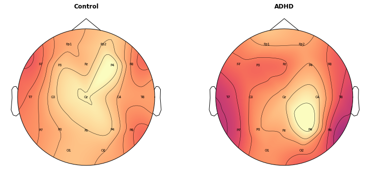

```python
fig, ax = plt.subplots(ncols=2, figsize=(13, 13), gridspec_kw=dict(top=0.9), sharex=True, sharey=True)

mne.viz.plot_topomap(list(temp1.min(axis = 0)), fake_evoked.info, axes = ax[0], show = False,cmap = 'magma',sensors = True,names = label_column,show_names = True)
mne.viz.plot_topomap(list(temp2.min(axis = 0)), fake_evoked.info, axes = ax[1], show = False,cmap = 'magma',sensors = True,names = label_column,show_names = True)

ax[0].set_title('Control', fontweight='bold')
ax[1].set_title('ADHD', fontweight='bold')
```

### Principal Component Analysis

```python
X = df_final.drop(['class'],axis=1)
y = df_final['class']
```

```python
pca = PCA(n_components=2)
x_pca = pca.fit_transform(X)
x_pca
```

```
array([[-2.19434926e-01,  4.72739426e-02],
       [ 2.52337048e-01,  3.84946307e-02],
       [ 3.51075015e-01,  2.80933790e-01],
       [ 2.04705401e-01, -3.88329065e-01],
       [-8.07016970e-01,  1.63606905e-02],
       [-2.95365520e-01,  1.70752440e-01],
       [-5.57945071e-01, -1.69444339e-01],
       [-6.42311027e-01, -2.54844955e-02],
       [ 9.66624867e-02, -5.77007990e-01],
       [ 5.35048511e-01,  2.44875314e-01],
       [ 9.20359946e-02,  3.65732008e-01],
       [-7.44277457e-01, -6.48303778e-02],
       [-6.90351074e-01, -4.24984865e-02],
       [ 1.53000873e-01,  2.36119606e-01],
       [-3.07007744e-01, -5.87943118e-02],
       [-4.02962025e-01, -4.27088480e-03],
       [-5.47248092e-01, -1.50608142e-01],
       [-6.29068522e-01, -1.67237279e-02],
       [-3.52839772e-01,  7.46039562e-03],
       [-3.14531383e-01, -1.27989956e-02],
       [-2.68598764e-01, -1.03971705e-01],
       [-5.28455551e-01,  1.03498576e-01],
       [-5.38871524e-01, -1.02622538e-01],
       [-2.83912927e-01,  1.17164372e-02],
       [-9.25635199e-01,  2.33092690e-02],
       [ 5.75262867e-02,  9.72720013e-02],
       [-3.17144514e-01,  2.76051726e-02],
       [-6.06223224e-01,  3.08286102e-02],
       [ 1.47960511e-01,  5.53036506e-01],
       [-6.62188532e-01, -3.05332611e-02],
       [ 1.20804941e-01,  9.95025479e-02],
       [ 5.09758908e-01, -2.87648187e-01],
       [ 8.53394459e-02,  2.02680029e-01],
       [-3.16245635e-01,  5.62970726e-02],
       [-1.98814709e-01,  3.37651385e-02],
       [ 7.26734301e-01, -5.62857551e-01],
       [ 5.88304989e-01,  1.60339579e-01],
       [-1.34588244e-01,  1.46637142e-02],
       [-4.15984681e-01,  3.68507828e-02],
       [-1.73071046e-01,  1.72502456e-01],
```

[output cut: 66 more lines]

```
       [ 1.87142489e-01, -5.26316435e-02],
       [ 2.94761823e-01,  2.30204262e-01],
       [ 5.67717281e-01, -1.13096076e-01],
       [-1.51844955e-01,  1.86345770e-01],
       [-1.31321667e-01, -7.30370462e-03],
       [-1.94296915e-01, -1.15740016e-01],
       [ 9.94608215e-02, -8.73167312e-02],
       [ 6.76317402e-01, -2.59679337e-01],
       [ 7.11252295e-01,  8.77748352e-01],
       [-4.87254801e-01,  5.85126803e-02],
       [ 3.02964034e-02, -4.07974039e-02],
       [-1.97035901e-01, -1.33835534e-01],
       [-3.03066198e-01, -1.59229035e-01],
       [-3.94470608e-01,  1.99215580e-01],
       [ 5.84489998e-01, -2.00351643e-01]])
```

```python
x_pca.shape
```

```
(121, 2)
```

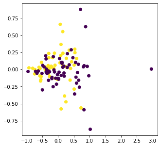

```python
# plot to check it is linearly separable or not
plt.figure(figsize = (5,5))
plt.scatter(x_pca[:,0],x_pca[:,1], c = y, cmap = 'viridis')
```

**The above plot is not linearly separable.**

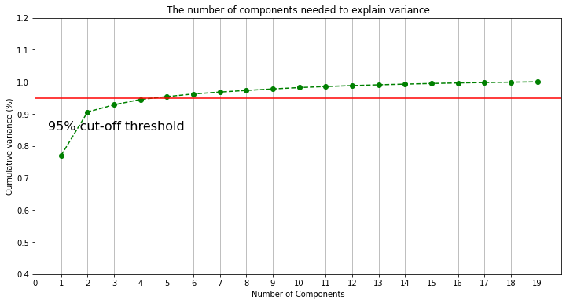

```python
# plot to find the optimal number of components for PCA
pca1 = PCA().fit(X)

plt.rcParams["figure.figsize"] = (12,6)

fig, ax = plt.subplots()
xi = np.arange(1, 20, step = 1)
y = np.cumsum(pca1.explained_variance_ratio_)

plt.ylim(0.4,1.2)
plt.plot(xi, y, marker='o', linestyle='--', color='g')

plt.xlabel('Number of Components')
plt.xticks(np.arange(0, 20, step=1))
plt.ylabel('Cumulative variance (%)')
plt.title('The number of components needed to explain variance')

plt.axhline(y = 0.95, color = 'r', linestyle = '-')
plt.text(0.5, 0.85, '95% cut-off threshold', color = 'black', fontsize = 16)

ax.grid(axis = 'x')
plt.show()
```

#### From the above plot, we can say thet the optimal value of hyperparameter in PCA is 5.

```python
pca1.explained_variance_ratio_
```

```
array([0.77094772, 0.13503246, 0.02215803, 0.01686089, 0.0088412 ,
       0.00825536, 0.00597906, 0.00505553, 0.00469873, 0.00430108,
       0.00325426, 0.00289671, 0.00239193, 0.00215643, 0.00197251,
       0.00163752, 0.00133571, 0.00117041, 0.00105447])
```

```python
# Optimum number of components
optimum_pca = PCA(n_components = 5)
X_final_PCA = optimum_pca.fit_transform(X)
```

```python
df_PCA = pd.DataFrame(X_final_PCA,columns=['PCA1','PCA2','PCA3','PCA4','PCA5'])
df_PCA
```

|  | PCA1 | PCA2 | PCA3 | PCA4 | PCA5 |
| --- | --- | --- | --- | --- | --- |
| 0 | -0.219435 | 0.047274 | 0.045662 | 0.059085 | 0.012727 |
| 1 | 0.252337 | 0.038495 | 0.000085 | 0.282938 | -0.051543 |
| 2 | 0.351075 | 0.280934 | 0.021629 | -0.073810 | -0.027603 |
| 3 | 0.204705 | -0.388329 | -0.021506 | 0.071740 | -0.078597 |
| 4 | -0.807017 | 0.016361 | -0.095151 | 0.027533 | -0.071296 |
| ... | ... | ... | ... | ... | ... |
| 116 | 0.030296 | -0.040797 | 0.116189 | -0.146387 | 0.006332 |
| 117 | -0.197036 | -0.133836 | -0.031429 | 0.035901 | 0.050012 |
| 118 | -0.303066 | -0.159229 | -0.068930 | -0.090357 | 0.011707 |
| 119 | -0.394471 | 0.199216 | 0.038811 | -0.070813 | -0.036190 |
| 120 | 0.584490 | -0.200352 | -0.056039 | -0.123809 | -0.054068 |

121 rows × 5 columns

## Machine Learning Algorithm

### Splitting the data using stratified k fold split

```python
X = df_final.drop('class',axis = 1)
y = df_final['class']
```

```python
skf = StratifiedKFold(n_splits = 4, random_state = None, shuffle = False)
```

```python
def plot_confusion_matrix_(y_test,y_pred):
    conf_matrix=[[0,0],[0,0]]
    y_test1 = [x for x in y_test]
    for i in range(0,len(y_test1)):
        if y_test1[i] == 1 and y_pred[i] == 1: # true positive
            conf_matrix[0][0] += 1
        elif y_test1[i] == 1 and y_pred[i] == 0: # false negative
            conf_matrix[0][1] += 1
        elif y_test1[i] == 0 and y_pred[i] == 1: # false positive
            conf_matrix[1][0] += 1
        elif y_test1[i] == 0 and y_pred[i] == 0: # true negative
            conf_matrix[1][1] += 1
    fig, ax = plt.subplots(figsize=(5, 5))
    ax.matshow(conf_matrix, cmap=plt.cm.Blues, alpha=0.3)
    for i in range(2):
        for j in range(2):
            ax.text(x=j, y=i,s=conf_matrix[i][j], va='center', ha='center', size='xx-large')

    plt.xlabel('Predictions', fontsize=18)
    plt.ylabel('Actuals', fontsize=18)
    plt.title('Confusion Matrix', fontsize=18)
    plt.show()
```

```python
def plot_roc_curve_(y_test,y_pred):
    fpr, tpr, thresholds = roc_curve(y_test, y_pred)
    roc_auc = roc_auc_score(y_test,y_pred)
    plt.plot(fpr, tpr, 'b', label = 'AUC = %0.2f' % roc_auc)
    plt.legend(loc = 'lower right')
    plt.title("ROC curve")
    plt.plot([0, 1], [0, 1],'r--')
    plt.xlim([0, 1])
    plt.ylim([0, 1])
    plt.ylabel('True Positive Rate')
    plt.xlabel('False Positive Rate')
    plt.show()
```

### Perceptron

```python
max0 = 0
y_pred_final_p = []
y_test_final_p = []
for train_index,test_index in skf.split(X, y):
    X_train_p,X_test_p = X.iloc[train_index], X.iloc[test_index]
    y_train_p,y_test_p = y.iloc[train_index], y.iloc[test_index]
    perceptron = Perceptron()
    penalty = ['l1', 'l2']
    alpha = [0.1, 0.01, 0.001, 0.0001, 0.00001]
    hyperparameters = dict(alpha = alpha, penalty = penalty)
    clf_p = GridSearchCV(perceptron, hyperparameters, cv=5, verbose=0) # finding optimal hyperparamter
    best_model = clf_p.fit(X_train_p, y_train_p)
    # Displaying the best hyperparameters
    print('Best Parameters',clf_p.best_params_)
    print('Best Penalty:', best_model.best_estimator_.get_params()['penalty'])
    print('Best C:', best_model.best_estimator_.get_params()['alpha'])
    y_pred_p = clf_p.predict(X_test_p)
    print("Accuracy Score: ", accuracy_score(y_test_p, y_pred_p))
    if accuracy_score(y_test_p, y_pred_p) > max0:
        max0 = accuracy_score(y_test_p, y_pred_p) # Storing the maximum accuarcy and coreesponding y_test and y_pred
        y_test_final_p = list(y_test_p)
        y_pred_final_p = list(y_pred_p)
        X_test_final_p = list(X_test_p)
```

```
Best Parameters {'alpha': 1e-05, 'penalty': 'l1'}
Best Penalty: l1
Best C: 1e-05
Accuracy Score:  0.6451612903225806
Best Parameters {'alpha': 0.001, 'penalty': 'l1'}
Best Penalty: l1
Best C: 0.001
Accuracy Score:  0.6
Best Parameters {'alpha': 0.001, 'penalty': 'l1'}
Best Penalty: l1
Best C: 0.001
Accuracy Score:  0.5
Best Parameters {'alpha': 1e-05, 'penalty': 'l2'}
Best Penalty: l2
Best C: 1e-05
Accuracy Score:  0.7
```

```
Accuracy for Perceptron model:  0.7
Precision for Perceptron model:  0.6666666666666666
Recall for Perceptron model:  0.8
F1 Score for Perceptron model:  0.7272727272727272
Classification Report:
               precision    recall  f1-score   support

           0       0.75      0.60      0.67        15
           1       0.67      0.80      0.73        15

    accuracy                           0.70        30
   macro avg       0.71      0.70      0.70        30
weighted avg       0.71      0.70      0.70        30
```

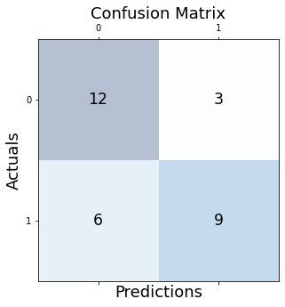

```
Confusion Matrix:
 None
ROC:  (array([0. , 0.4, 1. ]), array([0. , 0.8, 1. ]), array([2, 1, 0]))
Area Under the curve:  0.7000000000000001
ROC Curve:
```

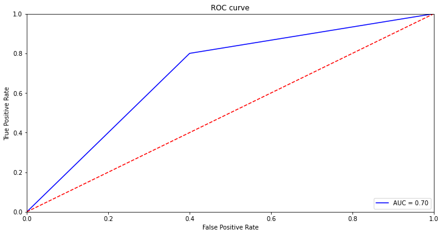

```python
#Evaluation Metrics
print("Accuracy for Perceptron model: ", accuracy_score(y_test_final_p, y_pred_final_p))
print("Precision for Perceptron model: ", precision_score(y_test_final_p, y_pred_final_p))
print("Recall for Perceptron model: ", recall_score(y_test_final_p, y_pred_final_p))
print("F1 Score for Perceptron model: ", f1_score(y_test_final_p, y_pred_final_p))
print("Classification Report: \n", classification_report(y_test_final_p, y_pred_final_p))
print("Confusion Matrix: \n", plot_confusion_matrix_(y_test_final_p, y_pred_final_p))
print("ROC: ",roc_curve(y_test_final_p, y_pred_final_p))
print("Area Under the curve: ", roc_auc_score(y_test_final_p, y_pred_final_p))
print("ROC Curve: \n")
plot_roc_curve_(y_test_final_p, y_pred_final_p)
```

### Logistic Regression

```python
max1 = 0
y_pred_final_l = []
y_test_final_l = []
for train_index,test_index in skf.split(X, y):
    X_train_l,X_test_l = X.iloc[train_index], X.iloc[test_index]
    y_train_l,y_test_l = y.iloc[train_index], y.iloc[test_index]
    logistic = LogisticRegression()
    penalty = ['l1', 'l2']
    C = [0.0001, 0.001, 0.01, 1, 100]
    hyperparameters = dict(C = C, penalty = penalty)
    clf_l = GridSearchCV(logistic, hyperparameters, cv=5, verbose=0) # finding optimal hyperparamter
    best_model = clf_l.fit(X_train_l, y_train_l)
    # Displaying the best hyperparameters
    print('Best Parameters',clf_l.best_params_)
    print('Best Penalty:', best_model.best_estimator_.get_params()['penalty'])
    print('Best C:', best_model.best_estimator_.get_params()['C'])
    y_pred_l = clf_l.predict(X_test_l)
    print("Accuracy Score: ", accuracy_score(y_test_l, y_pred_l))
    if accuracy_score(y_test_l, y_pred_l) > max1:
        max1 = accuracy_score(y_test_l, y_pred_l) # Storing the maximum accuarcy and coreesponding y_test and y_pred
        y_test_final_l = list(y_test_l)
        y_pred_final_l = list(y_pred_l)
        X_test_final_l = list(X_test_l)
```

```
Best Parameters {'C': 100, 'penalty': 'l2'}
Best Penalty: l2
Best C: 100
Accuracy Score:  0.7096774193548387
Best Parameters {'C': 100, 'penalty': 'l2'}
Best Penalty: l2
Best C: 100
Accuracy Score:  0.7
Best Parameters {'C': 100, 'penalty': 'l2'}
Best Penalty: l2
Best C: 100
Accuracy Score:  0.6666666666666666
Best Parameters {'C': 1, 'penalty': 'l2'}
Best Penalty: l2
Best C: 1
Accuracy Score:  0.6333333333333333
```

```
Accuracy for logistic regression:  0.7096774193548387
Precision for logistic regression:  0.7058823529411765
Recall for logistic regression:  0.75
F1 Score for logistic regression:  0.7272727272727272
Classification Report:
               precision    recall  f1-score   support

           0       0.71      0.67      0.69        15
           1       0.71      0.75      0.73        16

    accuracy                           0.71        31
   macro avg       0.71      0.71      0.71        31
weighted avg       0.71      0.71      0.71        31
```

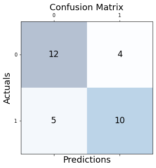

```
Confusion Matrix:
 None
ROC:  (array([0.        , 0.33333333, 1.        ]), array([0.  , 0.75, 1.  ]), array([2, 1, 0]))
Area Under the curve:  0.7083333333333334
ROC Curve:
```

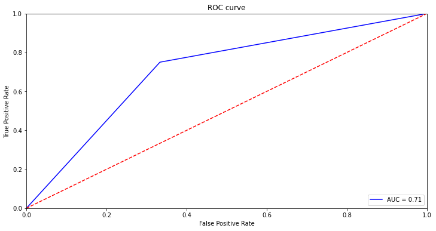

```python
print("Accuracy for logistic regression: ", accuracy_score(y_test_final_l, y_pred_final_l))
print("Precision for logistic regression: ", precision_score(y_test_final_l, y_pred_final_l))
print("Recall for logistic regression: ", recall_score(y_test_final_l, y_pred_final_l))
print("F1 Score for logistic regression: ", f1_score(y_test_final_l, y_pred_final_l))
print("Classification Report: \n", classification_report(y_test_final_l, y_pred_final_l))
print("Confusion Matrix: \n", plot_confusion_matrix_(y_test_final_l, y_pred_final_l))
print("ROC: ",roc_curve(y_test_final_l, y_pred_final_l))
print("Area Under the curve: ", roc_auc_score(y_test_final_l, y_pred_final_l))
print("ROC Curve: ")
plot_roc_curve_(y_test_final_l, y_pred_final_l)
```

### Support Vector Machines

```python
max2 = 0
y_pred_final_svm = []
y_test_final_svm = []
for train_index,test_index in skf.split(X, y):
    X_train_svm,X_test_svm = X.iloc[train_index], X.iloc[test_index]
    y_train_svm,y_test_svm = y.iloc[train_index], y.iloc[test_index]
    svm = SVC()
    hyperparameters = {'C': [1.00, 0.1, 1, 10, 100],
              'gamma': [1, 0.1, 0.01, 0.001, 0.0001],
              'kernel': ['rbf', 'linear', 'poly', 'sigmoid']}
    clf_svm = GridSearchCV(svm, hyperparameters, cv=5, verbose=0) # finding optimal hyperparamter
    best_model = clf_svm.fit(X_train_svm, y_train_svm)
    # Displaying the best hyperparameters
    print('Best Parameters',clf_svm.best_params_)
    print('Best Kernel:', best_model.best_estimator_.get_params()['kernel'])
    print('Best gamma:', best_model.best_estimator_.get_params()['gamma'])
    print('Best C:', best_model.best_estimator_.get_params()['C'])
    y_pred_svm = clf_svm.predict(X_test_svm)
    print("Accuracy Score: ", accuracy_score(y_test_svm, y_pred_svm))
    if accuracy_score(y_test_svm, y_pred_svm) > max2:
        max2 = accuracy_score(y_test_svm, y_pred_svm) # Storing the maximum accuarcy and coreesponding y_test and y_pred
        y_test_final_svm = list(y_test_svm)
        y_pred_final_svm = list(y_pred_svm)
        X_test_final_svm = list(X_test_svm)
```

```
Best Parameters {'C': 10, 'gamma': 1, 'kernel': 'rbf'}
Best Kernel: rbf
Best gamma: 1
Best C: 10
Accuracy Score:  0.6451612903225806
Best Parameters {'C': 10, 'gamma': 1, 'kernel': 'linear'}
Best Kernel: linear
Best gamma: 1
Best C: 10
Accuracy Score:  0.6333333333333333
Best Parameters {'C': 10, 'gamma': 1, 'kernel': 'rbf'}
Best Kernel: rbf
Best gamma: 1
Best C: 10
Accuracy Score:  0.7
Best Parameters {'C': 10, 'gamma': 1, 'kernel': 'linear'}
Best Kernel: linear
Best gamma: 1
Best C: 10
Accuracy Score:  0.8
```

```
Accuracy for Support Vector Machine:  0.8
Precision for Support Vector Machine:  0.8
Recall for Support Vector Machine:  0.8
F1 Score for Support Vector Machine:  0.8000000000000002
Classification Report:
               precision    recall  f1-score   support

           0       0.80      0.80      0.80        15
           1       0.80      0.80      0.80        15

    accuracy                           0.80        30
   macro avg       0.80      0.80      0.80        30
weighted avg       0.80      0.80      0.80        30
```

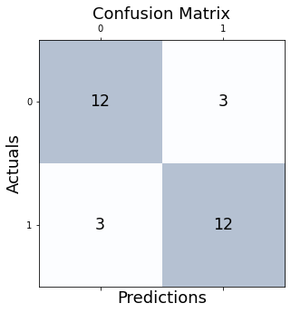

```
Confusion Matrix:
 None
ROC:  (array([0. , 0.2, 1. ]), array([0. , 0.8, 1. ]), array([2, 1, 0]))
Area Under the curve:  0.8
ROC Curve:
```

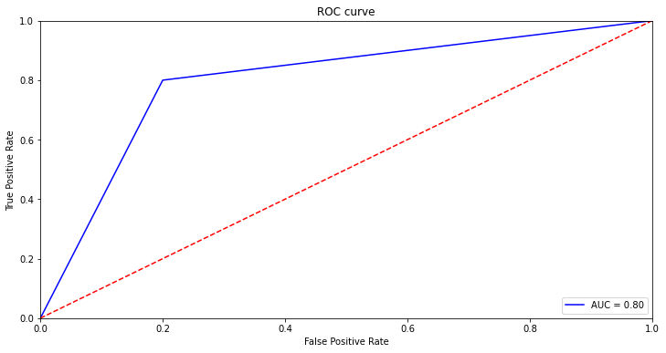

```python
print("Accuracy for Support Vector Machine: ", accuracy_score(y_test_final_svm, y_pred_final_svm))
print("Precision for Support Vector Machine: ", precision_score(y_test_final_svm, y_pred_final_svm))
print("Recall for Support Vector Machine: ", recall_score(y_test_final_svm, y_pred_final_svm))
print("F1 Score for Support Vector Machine: ", f1_score(y_test_final_svm, y_pred_final_svm))
print("Classification Report: \n", classification_report(y_test_final_svm, y_pred_final_svm))
print("Confusion Matrix: \n", plot_confusion_matrix_(y_test_final_svm, y_pred_final_svm))
print("ROC: ",roc_curve(y_test_final_svm, y_pred_final_svm))
print("Area Under the curve: ", roc_auc_score(y_test_final_svm, y_pred_final_svm))
print("ROC Curve: ")
plot_roc_curve_(y_test_final_svm, y_pred_final_svm)
```

### Naive Bayes Classifier

#### Bernoulli Naive Bayes

```python
#Bernoulli Naive Bayes
max3 = 0
y_pred_final_bnb = []
y_test_final_bnb = []
for train_index,test_index in skf.split(X, y):
    X_train_bnb,X_test_bnb = X.iloc[train_index], X.iloc[test_index]
    y_train_bnb,y_test_bnb = y.iloc[train_index], y.iloc[test_index]
    bernoulli = BernoulliNB()
    hyperparameters = {'alpha': [50, 40, 30, 10, 1, 0.1, 0.01]}
    clf_bnb = GridSearchCV(bernoulli, hyperparameters, cv=5, verbose=0) # finding optimal hyperparamter
    best_model = clf_bnb.fit(X_train_bnb, y_train_bnb)
    # Displaying the best hyperparameters
    print('Best Parameters',clf_bnb.best_params_)
    print('Best Alpha:', best_model.best_estimator_.get_params()['alpha'])
    y_pred_bnb = clf_bnb.predict(X_test_bnb)
    print("Accuracy Score: ", accuracy_score(y_test_bnb, y_pred_bnb))
    if accuracy_score(y_test_bnb, y_pred_bnb) > max3:
        max3 = accuracy_score(y_test_bnb, y_pred_bnb) # Storing the maximum accuarcy and coreesponding y_test and y_pred
        y_test_final_bnb = list(y_test_bnb)
        y_pred_final_bnb = list(y_pred_bnb)
        X_test_final_bnb = list(X_test_bnb)
```

```
Best Parameters {'alpha': 50}
Best Alpha: 50
Accuracy Score:  0.4838709677419355
Best Parameters {'alpha': 50}
Best Alpha: 50
Accuracy Score:  0.5
Best Parameters {'alpha': 50}
Best Alpha: 50
Accuracy Score:  0.5
Best Parameters {'alpha': 50}
Best Alpha: 50
Accuracy Score:  0.5
```

```
Accuracy for Bernoulli Naive Bayes:  0.5
Precision for Bernoulli Naive Bayes:  0.5
Recall for Bernoulli Naive Bayes:  1.0
F1 Score for Bernoulli Naive Bayes:  0.6666666666666666
Classification Report:
               precision    recall  f1-score   support

           0       0.00      0.00      0.00        15
           1       0.50      1.00      0.67        15

    accuracy                           0.50        30
   macro avg       0.25      0.50      0.33        30
weighted avg       0.25      0.50      0.33        30
```

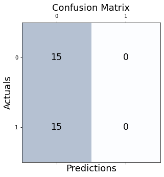

```
Confusion Matrix:
 None
ROC:  (array([0., 1.]), array([0., 1.]), array([2, 1]))
Area Under the curve:  0.5
ROC Curve:
```

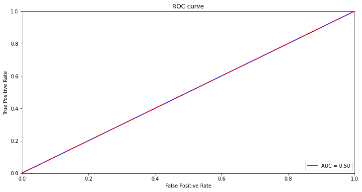

```python
print("Accuracy for Bernoulli Naive Bayes: ", accuracy_score(y_test_final_bnb, y_pred_final_bnb))
print("Precision for Bernoulli Naive Bayes: ", precision_score(y_test_final_bnb, y_pred_final_bnb))
print("Recall for Bernoulli Naive Bayes: ", recall_score(y_test_final_bnb, y_pred_final_bnb))
print("F1 Score for Bernoulli Naive Bayes: ", f1_score(y_test_final_bnb, y_pred_final_bnb))
print("Classification Report: \n", classification_report(y_test_final_bnb, y_pred_final_bnb))
print("Confusion Matrix: \n", plot_confusion_matrix_(y_test_final_bnb, y_pred_final_bnb))
print("ROC: ",roc_curve(y_test_final_bnb, y_pred_final_bnb))
print("Area Under the curve: ", roc_auc_score(y_test_final_bnb, y_pred_final_bnb))
print("ROC Curve: ")
plot_roc_curve_(y_test_final_bnb, y_pred_final_bnb)
```

#### Gaussian Naive Bayes

```python
#Gaussian Naive Bayes
max4 = 0
y_pred_final_gnb = []
y_test_final_gnb = []
for train_index,test_index in skf.split(X, y):
    X_train_gnb,X_test_gnb = X.iloc[train_index], X.iloc[test_index]
    y_train_gnb,y_test_gnb = y.iloc[train_index], y.iloc[test_index]
    gaussian = GaussianNB()
    hyperparameters = {'var_smoothing': [ 0.1, 0.01, 0.001, 0.0001, 0.00001]}
    clf_gnb = GridSearchCV(gaussian, hyperparameters, cv=5, verbose=0) # finding optimal hyperparamter
    best_model = clf_gnb.fit(X_train_gnb, y_train_gnb)
    # Displaying the best hyperparameters
    print('Best Parameters',clf_gnb.best_params_)
    print('Best var_smoothing:', best_model.best_estimator_.get_params()['var_smoothing'])
    y_pred_gnb = clf_gnb.predict(X_test_gnb)
    print("Accuracy Score: ", accuracy_score(y_test_gnb, y_pred_gnb))
    if accuracy_score(y_test_gnb, y_pred_gnb) > max4:
        max4 = accuracy_score(y_test_gnb, y_pred_gnb) # Storing the maximum accuarcy and coreesponding y_test and y_pred
        y_test_final_gnb = list(y_test_gnb)
        y_pred_final_gnb = list(y_pred_gnb)
        X_test_final_gnb = list(X_test_gnb)
```

```
Best Parameters {'var_smoothing': 0.1}
Best var_smoothing: 0.1
Accuracy Score:  0.6774193548387096
Best Parameters {'var_smoothing': 0.01}
Best var_smoothing: 0.01
Accuracy Score:  0.5333333333333333
Best Parameters {'var_smoothing': 0.01}
Best var_smoothing: 0.01
Accuracy Score:  0.5
Best Parameters {'var_smoothing': 0.001}
Best var_smoothing: 0.001
Accuracy Score:  0.4666666666666667
```

```
Accuracy for Gaussian Naive Bayes:  0.6774193548387096
Precision for Gaussian Naive Bayes:  0.6875
Recall for Gaussian Naive Bayes:  0.6875
F1 Score for Gaussian Naive Bayes:  0.6875
Classification Report:
               precision    recall  f1-score   support

           0       0.67      0.67      0.67        15
           1       0.69      0.69      0.69        16

    accuracy                           0.68        31
   macro avg       0.68      0.68      0.68        31
weighted avg       0.68      0.68      0.68        31
```

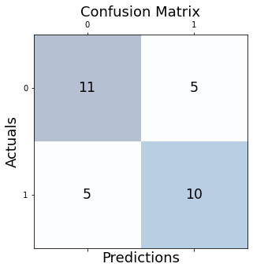

```
Confusion Matrix:
 None
ROC:  (array([0.        , 0.33333333, 1.        ]), array([0.    , 0.6875, 1.    ]), array([2, 1, 0]))
Area Under the curve:  0.6770833333333335
ROC Curve:
```

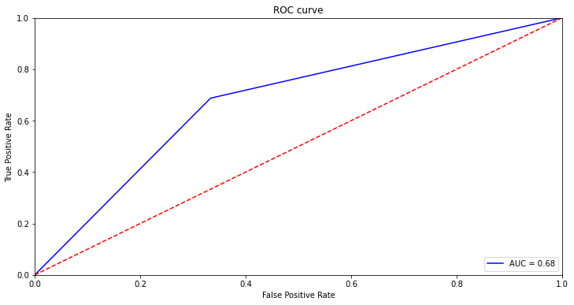

```python
print("Accuracy for Gaussian Naive Bayes: ", accuracy_score(y_test_final_gnb, y_pred_final_gnb))
print("Precision for Gaussian Naive Bayes: ", precision_score(y_test_final_gnb, y_pred_final_gnb))
print("Recall for Gaussian Naive Bayes: ", recall_score(y_test_final_gnb, y_pred_final_gnb))
print("F1 Score for Gaussian Naive Bayes: ", f1_score(y_test_final_gnb, y_pred_final_gnb))
print("Classification Report: \n", classification_report(y_test_final_gnb, y_pred_final_gnb))
print("Confusion Matrix: \n", plot_confusion_matrix_(y_test_final_gnb, y_pred_final_gnb))
print("ROC: ",roc_curve(y_test_final_gnb, y_pred_final_gnb))
print("Area Under the curve: ", roc_auc_score(y_test_final_gnb, y_pred_final_gnb))
print("ROC Curve: ")
plot_roc_curve_(y_test_final_gnb, y_pred_final_gnb)
```

### K Nearest Neighbors(KNN)

```python
max5 = 0
y_pred_final_knn = []
y_test_final_knn = []
for train_index,test_index in skf.split(X, y):
    X_train_knn,X_test_knn = X.iloc[train_index], X.iloc[test_index]
    y_train_knn,y_test_knn = y.iloc[train_index], y.iloc[test_index]
    knn = KNeighborsClassifier()
    hyperparameters = {'n_neighbors': [1, 2, 4, 5, 7, 8, 9, 10, 15, 25],
              'p': [1, 2],
              'weights': ['uniform', 'distance']}
    clf_knn = GridSearchCV(knn, hyperparameters, cv=5, verbose=0) # finding optimal hyperparamter
    best_model = clf_knn.fit(X_train_knn, y_train_knn)
    # Displaying the best hyperparameters
    print('Best Parameters',clf_knn.best_params_)
    print('Best n_neighbors:', best_model.best_estimator_.get_params()['n_neighbors'])
    print('Best p:', best_model.best_estimator_.get_params()['p'])
    print('Best weights:', best_model.best_estimator_.get_params()['weights'])
    y_pred_knn = clf_knn.predict(X_test_knn)
    print("Accuracy Score: ", accuracy_score(y_test_knn, y_pred_knn))
    if accuracy_score(y_test_knn, y_pred_knn) > max5:
        max5 = accuracy_score(y_test_knn, y_pred_knn) # Storing the maximum accuarcy and coreesponding y_test and y_pred
        y_test_final_knn = list(y_test_knn)
        y_pred_final_knn = list(y_pred_knn)
        X_test_final_knn = list(X_test_knn)
```

```
Best Parameters {'n_neighbors': 15, 'p': 1, 'weights': 'distance'}
Best n_neighbors: 15
Best p: 1
Best weights: distance
Accuracy Score:  0.7096774193548387
Best Parameters {'n_neighbors': 7, 'p': 2, 'weights': 'distance'}
Best n_neighbors: 7
Best p: 2
Best weights: distance
Accuracy Score:  0.6333333333333333
Best Parameters {'n_neighbors': 7, 'p': 1, 'weights': 'distance'}
Best n_neighbors: 7
Best p: 1
Best weights: distance
Accuracy Score:  0.6666666666666666
Best Parameters {'n_neighbors': 8, 'p': 1, 'weights': 'uniform'}
Best n_neighbors: 8
Best p: 1
Best weights: uniform
Accuracy Score:  0.6
```

```
Accuracy for KNeighborsClassifier:  0.7096774193548387
Precision for KNeighborsClassifier:  0.6666666666666666
Recall for KNeighborsClassifier:  0.875
F1 Score for KNeighborsClassifier:  0.7567567567567567
Classification Report:
               precision    recall  f1-score   support

           0       0.80      0.53      0.64        15
           1       0.67      0.88      0.76        16

    accuracy                           0.71        31
   macro avg       0.73      0.70      0.70        31
weighted avg       0.73      0.71      0.70        31
```

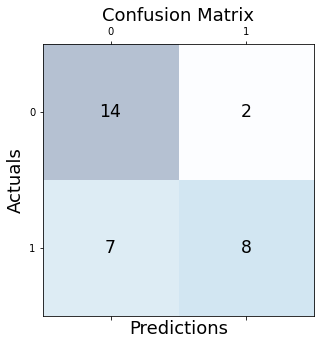

```
Confusion Matrix:
 None
ROC:  (array([0.        , 0.46666667, 1.        ]), array([0.   , 0.875, 1.   ]), array([2, 1, 0]))
Area Under the curve:  0.7041666666666666
ROC Curve:
```

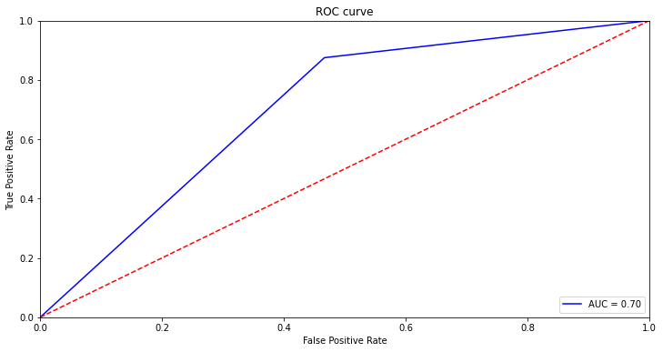

```python
print("Accuracy for KNeighborsClassifier: ", accuracy_score(y_test_final_knn, y_pred_final_knn))
print("Precision for KNeighborsClassifier: ", precision_score(y_test_final_knn, y_pred_final_knn))
print("Recall for KNeighborsClassifier: ", recall_score(y_test_final_knn, y_pred_final_knn))
print("F1 Score for KNeighborsClassifier: ", f1_score(y_test_final_knn, y_pred_final_knn))
print("Classification Report: \n", classification_report(y_test_final_knn, y_pred_final_knn))
print("Confusion Matrix: \n", plot_confusion_matrix_(y_test_final_knn, y_pred_final_knn))
print("ROC: ",roc_curve(y_test_final_knn, y_pred_final_knn))
print("Area Under the curve: ", roc_auc_score(y_test_final_knn, y_pred_final_knn))
print("ROC Curve: ")
plot_roc_curve_(y_test_final_knn, y_pred_final_knn)
```

### Decision Tree

```python
max6 = 0
y_pred_final_dt = []
y_test_final_dt = []
for train_index,test_index in skf.split(X, y):
    X_train_dt,X_test_dt = X.iloc[train_index], X.iloc[test_index]
    y_train_dt,y_test_dt = y.iloc[train_index], y.iloc[test_index]
    dt = DecisionTreeClassifier()
    hyperparameters = {'criterion':['gini', 'entropy'],
                       'max_depth': [2, 3, 4, 5, 6, 7, 10],
                       'min_samples_split':[3, 4, 5, 6, 7]}
    clf_dt = GridSearchCV(dt, hyperparameters, cv=5, verbose=0) # finding optimal hyperparamter
    best_model = clf_dt.fit(X_train_dt, y_train_dt)
    # Displaying the best hyperparameters
    print('Best Parameters',clf_dt.best_params_)
    print('Best criterion:', best_model.best_estimator_.get_params()['criterion'])
    print('Best max_depth:', best_model.best_estimator_.get_params()['max_depth'])
    print('Best min_samples_split:', best_model.best_estimator_.get_params()['min_samples_split'])
    y_pred_dt = clf_dt.predict(X_test_dt)
    print("Accuracy Score: ", accuracy_score(y_test_dt, y_pred_dt))
    if accuracy_score(y_test_dt, y_pred_dt) > max6:
        max6 = accuracy_score(y_test_dt, y_pred_dt) # Storing the maximum accuarcy and coreesponding y_test and y_pred
        y_test_final_dt = list(y_test_dt)
        y_pred_final_dt = list(y_pred_dt)
        X_test_final_dt = list(X_test_dt)
```

```
Best Parameters {'criterion': 'entropy', 'max_depth': 7, 'min_samples_split': 7}
Best criterion: entropy
Best max_depth: 7
Best min_samples_split: 7
Accuracy Score:  0.5483870967741935
Best Parameters {'criterion': 'gini', 'max_depth': 10, 'min_samples_split': 3}
Best criterion: gini
Best max_depth: 10
Best min_samples_split: 3
Accuracy Score:  0.6666666666666666
Best Parameters {'criterion': 'entropy', 'max_depth': 5, 'min_samples_split': 5}
Best criterion: entropy
Best max_depth: 5
Best min_samples_split: 5
Accuracy Score:  0.6
Best Parameters {'criterion': 'gini', 'max_depth': 2, 'min_samples_split': 3}
Best criterion: gini
Best max_depth: 2
Best min_samples_split: 3
Accuracy Score:  0.6
```

```
Accuracy for DecisionTreeClassifier:  0.6666666666666666
Precision for DecisionTreeClassifier:  0.6923076923076923
Recall for DecisionTreeClassifier:  0.6
F1 Score for DecisionTreeClassifier:  0.6428571428571429
Classification Report:
               precision    recall  f1-score   support

           0       0.65      0.73      0.69        15
           1       0.69      0.60      0.64        15

    accuracy                           0.67        30
   macro avg       0.67      0.67      0.67        30
weighted avg       0.67      0.67      0.67        30
```

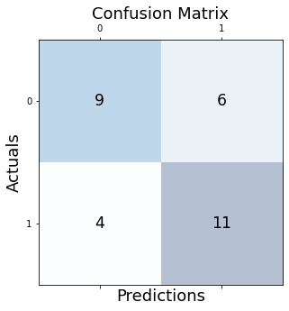

```
Confusion Matrix:
 None
ROC:  (array([0.        , 0.26666667, 1.        ]), array([0. , 0.6, 1. ]), array([2, 1, 0]))
Area Under the curve:  0.6666666666666667
ROC Curve:
```

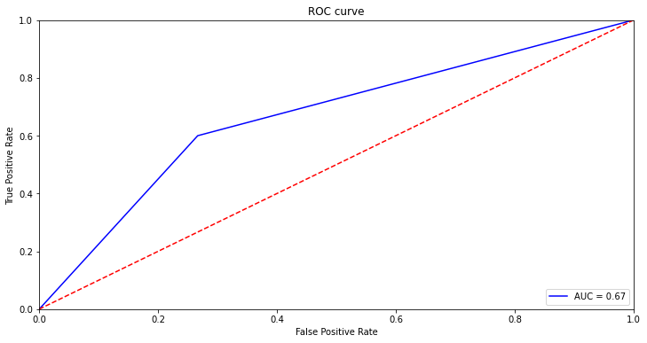

```python
print("Accuracy for DecisionTreeClassifier: ", accuracy_score(y_test_final_dt, y_pred_final_dt))
print("Precision for DecisionTreeClassifier: ", precision_score(y_test_final_dt, y_pred_final_dt))
print("Recall for DecisionTreeClassifier: ", recall_score(y_test_final_dt, y_pred_final_dt))
print("F1 Score for DecisionTreeClassifier: ", f1_score(y_test_final_dt, y_pred_final_dt))
print("Classification Report: \n", classification_report(y_test_final_dt, y_pred_final_dt))
print("Confusion Matrix: \n", plot_confusion_matrix_(y_test_final_dt, y_pred_final_dt))
print("ROC: ",roc_curve(y_test_final_dt, y_pred_final_dt))
print("Area Under the curve: ", roc_auc_score(y_test_final_dt, y_pred_final_dt))
print("ROC Curve: ")
plot_roc_curve_(y_test_final_dt, y_pred_final_dt)
```

#### Random Forest

```python
max7 = 0
y_pred_final_rf = []
y_test_final_rf = []
for train_index,test_index in skf.split(X, y):
    X_train_rf,X_test_rf = X.iloc[train_index], X.iloc[test_index]
    y_train_rf,y_test_rf = y.iloc[train_index], y.iloc[test_index]
    rf = RandomForestClassifier()
    hyperparameters = {'criterion':['gini', 'entropy'],
                       'max_depth': [5, 6, 7, 10, 12, 15],
                       'min_samples_split':[2, 3, 4]}
    clf_rf = GridSearchCV(rf, hyperparameters, cv=5, verbose=0) # finding optimal hyperparamter
    best_model = clf_rf.fit(X_train_rf, y_train_rf)
    # Displaying the best hyperparameters
    print('Best Parameters',clf_rf.best_params_)
    print('Best criterion:', best_model.best_estimator_.get_params()['criterion'])
    print('Best max_depth:', best_model.best_estimator_.get_params()['max_depth'])
    print('Best min_samples_split:', best_model.best_estimator_.get_params()['min_samples_split'])
    y_pred_rf = clf_rf.predict(X_test_rf)
    print("Accuracy Score: ", accuracy_score(y_test_rf, y_pred_rf))
    if accuracy_score(y_test_rf, y_pred_rf) > max7:
        max7 = accuracy_score(y_test_rf, y_pred_rf) # Storing the maximum accuarcy and coreesponding y_test and y_pred
        y_test_final_rf = list(y_test_rf)
        y_pred_final_rf = list(y_pred_rf)
        X_test_final_rf = list(X_test_rf)
```

```
Best Parameters {'criterion': 'entropy', 'max_depth': 10, 'min_samples_split': 2}
Best criterion: entropy
Best max_depth: 10
Best min_samples_split: 2
Accuracy Score:  0.7096774193548387
Best Parameters {'criterion': 'entropy', 'max_depth': 6, 'min_samples_split': 3}
Best criterion: entropy
Best max_depth: 6
Best min_samples_split: 3
Accuracy Score:  0.6666666666666666
Best Parameters {'criterion': 'gini', 'max_depth': 10, 'min_samples_split': 2}
Best criterion: gini
Best max_depth: 10
Best min_samples_split: 2
Accuracy Score:  0.6666666666666666
Best Parameters {'criterion': 'entropy', 'max_depth': 7, 'min_samples_split': 2}
Best criterion: entropy
Best max_depth: 7
Best min_samples_split: 2
Accuracy Score:  0.6666666666666666
```

```
Accuracy for Random Forest Classifier:  0.7096774193548387
Precision for Random Forest Classifier:  0.7333333333333333
Recall for Random Forest Classifier:  0.6875
F1 Score for Random Forest Classifier:  0.7096774193548386
Classification Report:
               precision    recall  f1-score   support

           0       0.69      0.73      0.71        15
           1       0.73      0.69      0.71        16

    accuracy                           0.71        31
   macro avg       0.71      0.71      0.71        31
weighted avg       0.71      0.71      0.71        31
```

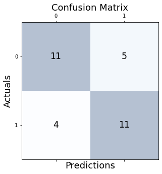

```
Confusion Matrix:
 None
ROC:  (array([0.        , 0.26666667, 1.        ]), array([0.    , 0.6875, 1.    ]), array([2, 1, 0]))
Area Under the curve:  0.7104166666666667
ROC Curve:
```

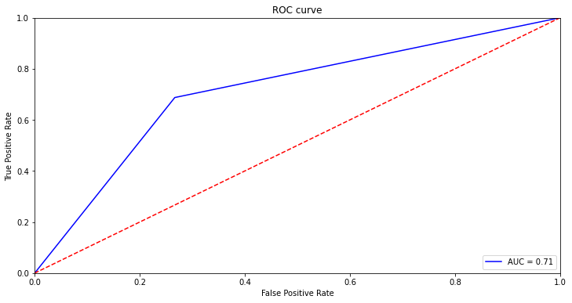

```python
print("Accuracy for Random Forest Classifier: ", accuracy_score(y_test_final_rf, y_pred_final_rf))
print("Precision for Random Forest Classifier: ", precision_score(y_test_final_rf, y_pred_final_rf))
print("Recall for Random Forest Classifier: ", recall_score(y_test_final_rf, y_pred_final_rf))
print("F1 Score for Random Forest Classifier: ", f1_score(y_test_final_rf, y_pred_final_rf))
print("Classification Report: \n", classification_report(y_test_final_rf, y_pred_final_rf))
print("Confusion Matrix: \n", plot_confusion_matrix_(y_test_final_rf, y_pred_final_rf))
print("ROC: ",roc_curve(y_test_final_rf, y_pred_final_rf))
print("Area Under the curve: ", roc_auc_score(y_test_final_rf, y_pred_final_rf))
print("ROC Curve: ")
plot_roc_curve_(y_test_final_rf, y_pred_final_rf)
```

# Summary

- The dataset used for prediction is ADHD dataset.
- At first, the matlab(.mat) files are converted to the csv file using scipy.
- Since, the number of rows in all the files are different, so minimum number of rows from the all the files is calculated and extracted only minimum number of rows in all the csv files.
- Then, mutual information for every subject was calculated and then calculated average mutual information for every feature in that mutual information matrix.
- Average mutual information of all the files are combined to a single dataframe.
- Class labels are also added to the corresponding rows(1 corresponds to ADHD and 0 corresponds to healthy control).
- Data visualization, like topoplot is displayed for each class in this notebook.
- Performed Principal Component Analysis(PCA) on the combined dataset and reduced the dataset to two dimension.
- Plotted the dataset to infer whether the dataset is linearly separable or not. Resulted in linearly non separable data.
- Then, optimum number of dimensions in PCA was found(optimum value is 5).
- Trained the before combined data with different machine algorithms and performed different evaluation metrics.
- The below table shows all the accuracy score of the models and the respective model name.

**Accuracy Scores of different models:**

---------------------------------------------------------------------  
| Model | Accuracy Score |  
---------------------------------------------------------------------

Perceptron - 0.70

Logistic Regression - 0.71

SVM - 0.80

Bernoulli Naive Bayes - 0.50

Gaussian Naive Bayes - 0.68

KNN - 0.71

**From the above table, we can conclude that Support Vector Machines(SVM) with best parameters as C = 10, gamma = 1, kernel 'linear' yields the best accuracy(0.80 i.e, 80% accuracy) and this model can be used for further predictions for best results.**